# Results & Analysis Builder (Paper-Ready)

This notebook is tailored to fill `\section{Results \& Analysis}` using artifacts under `../experiments/results`.

It produces:

- consolidated tables (CSV + LaTeX),
- paper figures with your TODO filenames (PDF + PNG),
- short auto-generated text snippets for the Results narrative.

## Section mapping

- **Overall comparison** → `tab_overall_results.*`
- **Energy efficiency** → `TODO_energy_time.*`, `TODO_sec_by_load.*`
- **QoS compliance** → `TODO_qos_time.*`
- **Orchestration stability** → `TODO_configs_time.*`, `TODO_reconf_stats.*`
- **Ablation** → `tab_ablation_obs.*`
- **Sensitivity** → `TODO_sensitivity_ic.*`

```python
from pathlib import Path
import ast
import re
import numpy as np
import pandas as pd
import matplotlib.pyplot as plt
import seaborn as sns

pd.set_option('display.max_columns', None)
pd.set_option('display.width', 220)

sns.set_theme(style='whitegrid', context='paper')
plt.rcParams.update({
    'figure.dpi': 130,
    'savefig.dpi': 300,
    'font.size': 10,
})

RESULTS_ROOT = Path('../experiments/results')
A1_ROOT = RESULTS_ROOT / 'A1_policy_observation'
B2_ROOT = RESULTS_ROOT / 'B2_top2_seeds'
C1_ROOT = RESULTS_ROOT / 'C1_cooldown_instances'
D1_ROOT = RESULTS_ROOT / 'D1_mlp_lstm_cd4_k_threshold'
BASELINES_ROOT = RESULTS_ROOT / 'Baselines'

PAPER_OUT = RESULTS_ROOT / 'paper_results_assets'
PAPER_OUT.mkdir(parents=True, exist_ok=True)

STEP_HOURS = 0.25  # 15-min control interval
TAU = 0.90
EPS = 1e-6

A1_SUMMARY_CSV = A1_ROOT / 'evaluation_analytics_summary.csv'
A1_BY_POLICY_CSV = A1_ROOT / 'evaluation_analytics_by_policy.csv'
A1_BY_OBS_CSV = A1_ROOT / 'evaluation_analytics_by_observation.csv'
D1_BASELINES_CSV = D1_ROOT / 'analysis' / 'd1_k2_t90_vs_baselines.csv'
C1_CD_SENS_CSV = C1_ROOT / 'analysis' / 'c1_cooldown_sensitivity_k2.csv'

for p in [A1_SUMMARY_CSV, D1_BASELINES_CSV, C1_CD_SENS_CSV]:
    assert p.exists(), f'Missing required file: {p.resolve()}'

print('Output folder:', PAPER_OUT.resolve())
```

```
Output folder: /home/ubuntu/EnergyAwareUPF/experiments/results/paper_results_assets
```

```python
def _read_csv(path: Path) -> pd.DataFrame:
    df = pd.read_csv(path)
    if df.empty:
        raise ValueError(f'Empty CSV: {path}')
    return df

def _enforce_rl_720_steps(df: pd.DataFrame, expected_steps: int = 720) -> pd.DataFrame:
    if df is None or len(df) == 0:
        return df.copy()

    n = len(df)
    if n == expected_steps + 1:
        # Common case: RL trace has one extra initial step
        return df.iloc[1:].reset_index(drop=True)
    if n > expected_steps:
        # Fallback: keep the last expected_steps rows
        return df.tail(expected_steps).reset_index(drop=True)
    return df.reset_index(drop=True)

def _parse_upf_code(val):
    if pd.isna(val):
        return np.nan
    try:
        cfg = ast.literal_eval(str(val))
        if isinstance(cfg, tuple) and len(cfg) >= 2:
            mode = str(cfg[0]).upper()
            inst = int(cfg[1])
            return 0 if mode == 'DPDK' else inst
    except Exception:
        return np.nan
    return np.nan

def _n_reconf(action_series: pd.Series) -> int:
    action = pd.to_numeric(action_series, errors='coerce')
    return int((action.diff().fillna(0) != 0).sum())

def _dwell_lengths(action_series: pd.Series) -> list[int]:
    action = pd.to_numeric(action_series, errors='coerce').dropna().to_numpy()
    if len(action) == 0:
        return []
    runs = []
    cur = action[0]
    ln = 1
    for a in action[1:]:
        if a == cur:
            ln += 1
        else:
            runs.append(ln)
            cur = a
            ln = 1
    runs.append(ln)
    return runs

def _controller_label(config: str) -> str:
    mapping = {
        'mlp_hybrid': 'PPO (feed-forward)',
        'lstm_history': 'PPO (recurrent)',
        'baseline_rule': 'Rule-based baseline',
        'baseline_static_dpdk': 'Static DPDK',
        'baseline_static_oai1x': 'Static USR(k=1)',
    }
    return mapping.get(config, config)
```

```python
a1_summary = _read_csv(A1_SUMMARY_CSV)
d1_comp = _read_csv(D1_BASELINES_CSV)
a1_by_policy = _read_csv(A1_BY_POLICY_CSV) if A1_BY_POLICY_CSV.exists() else pd.DataFrame()
a1_by_obs = _read_csv(A1_BY_OBS_CSV) if A1_BY_OBS_CSV.exists() else pd.DataFrame()
c1_cd = _read_csv(C1_CD_SENS_CSV)

display(a1_summary.head(3))
display(d1_comp)
```

|  | group | config | seed | run_dir | eval_csv | steps | switch_dpdk_to_oai | switch_oai_to_dpdk | scale_up | scale_down | cooldown_blocked | avg_sec | total_power | violation_rate | avg_qos | qos_threshold |
| --- | --- | --- | --- | --- | --- | --- | --- | --- | --- | --- | --- | --- | --- | --- | --- | --- |
| 0 | A1_policy_observation | lstm_forecast | seed_456 | ../experiments/results/A1_policy_observation/l... | ../experiments/results/A1_policy_observation/l... | 721 | 0 | 0 | 0 | 0 | 0 | 0.013528 | 591.169839 | 0.000000 | 0.973202 | 0.9 |
| 1 | A1_policy_observation | lstm_history | seed_456 | ../experiments/results/A1_policy_observation/l... | ../experiments/results/A1_policy_observation/l... | 721 | 8 | 8 | 0 | 0 | 7 | 0.007641 | 502.974575 | 0.001387 | 0.955212 | 0.9 |
| 2 | A1_policy_observation | lstm_hybrid | seed_456 | ../experiments/results/A1_policy_observation/l... | ../experiments/results/A1_policy_observation/l... | 721 | 7 | 7 | 5 | 6 | 20 | 0.010073 | 529.530100 | 0.004161 | 0.964272 | 0.9 |

|  | system | source | switching_count | scaling_count | avg_qos | violation_rate | total_energy_wh | avg_power_w | avg_sec |
| --- | --- | --- | --- | --- | --- | --- | --- | --- | --- |
| 0 | lstm_history | D1 RL | 16 | 0 | 0.955212 | 0.001387 | 125.743644 | 0.697607 | 0.007641 |
| 1 | mlp_hybrid | D1 RL | 17 | 7 | 0.954665 | 0.001387 | 120.790009 | 0.670125 | 0.007350 |
| 2 | baseline_rule | Baseline CSV | 24 | 0 | 0.960069 | 0.001389 | 123.923325 | 0.688463 | 0.007751 |
| 3 | baseline_static_dpdk | Baseline CSV | 0 | 0 | 0.973199 | 0.000000 | 147.586982 | 0.819928 | 0.013547 |
| 4 | baseline_static_oai1x | Baseline CSV | 0 | 0 | 0.924302 | 0.001389 | 178.357874 | 0.990877 | 0.009075 |

```python
# ---- Table: overall comparison (tab:overall_results) ----
tbl_overall = d1_comp.copy()
tbl_overall['Controller'] = tbl_overall['system'].map(_controller_label)
tbl_overall['E_tot'] = pd.to_numeric(tbl_overall['total_energy_wh'], errors='coerce')
tbl_overall['avg_SEC'] = pd.to_numeric(tbl_overall['avg_sec'], errors='coerce')
tbl_overall['v'] = pd.to_numeric(tbl_overall['violation_rate'], errors='coerce')
tbl_overall['n_reconf'] = pd.to_numeric(tbl_overall['switching_count'], errors='coerce')

order = [
    'PPO (feed-forward)',
    'PPO (recurrent)',
    'Rule-based baseline',
    'Static DPDK',
    'Static USR(k=1)'
]
tbl_overall['Controller'] = pd.Categorical(tbl_overall['Controller'], categories=order, ordered=True)
tbl_overall = tbl_overall.sort_values('Controller')[['Controller', 'E_tot', 'avg_SEC', 'v', 'n_reconf']].reset_index(drop=True)

display(tbl_overall.round({'E_tot': 2, 'avg_SEC': 5, 'v': 4, 'n_reconf': 0}))

overall_csv = PAPER_OUT / 'tab_overall_results.csv'
overall_tex = PAPER_OUT / 'tab_overall_results.tex'
tbl_overall.to_csv(overall_csv, index=False)
tbl_overall.to_latex(overall_tex, index=False, float_format='%.6g')

print('Saved:', overall_csv.resolve())
print('Saved:', overall_tex.resolve())
```

|  | Controller | E_tot | avg_SEC | v | n_reconf |
| --- | --- | --- | --- | --- | --- |
| 0 | PPO (feed-forward) | 120.79 | 0.00735 | 0.0014 | 17 |
| 1 | PPO (recurrent) | 125.74 | 0.00764 | 0.0014 | 16 |
| 2 | Rule-based baseline | 123.92 | 0.00775 | 0.0014 | 24 |
| 3 | Static DPDK | 147.59 | 0.01355 | 0.0000 | 0 |
| 4 | Static USR(k=1) | 178.36 | 0.00908 | 0.0014 | 0 |

|  | Controller | E_tot | avg_SEC | v | n_reconf |
| --- | --- | --- | --- | --- | --- |
| 0 | PPO (feed-forward) | 120.79 | 0.00735 | 0.0014 | 17 |
| 1 | PPO (recurrent) | 125.74 | 0.00764 | 0.0014 | 16 |
| 2 | Rule-based baseline | 123.92 | 0.00775 | 0.0014 | 24 |
| 3 | Static DPDK | 147.59 | 0.01355 | 0.0000 | 0 |
| 4 | Static USR(k=1) | 178.36 | 0.00908 | 0.0014 | 0 |

```
Saved: /home/ubuntu/EnergyAwareUPF/experiments/results/paper_results_assets/tab_overall_results.csv
Saved: /home/ubuntu/EnergyAwareUPF/experiments/results/paper_results_assets/tab_overall_results.tex
```

```python
# ---- Time-series loaders for figures ----
def load_rl_timeline(config_name: str) -> pd.DataFrame:
    row = a1_summary[a1_summary['config'] == config_name]
    if row.empty:
        raise ValueError(f'Missing config in A1 summary: {config_name}')
    eval_csv = Path(row.iloc[0]['eval_csv'])
    if not eval_csv.exists():
        eval_csv = (Path.cwd() / eval_csv).resolve()
    df = pd.read_csv(eval_csv)
    df = _enforce_rl_720_steps(df)
    out = pd.DataFrame({
        't': np.arange(len(df)),
        'traffic': pd.to_numeric(df.get('traffic'), errors='coerce'),
        'power': pd.to_numeric(df.get('power'), errors='coerce'),
        'qos': pd.to_numeric(df.get('performance'), errors='coerce'),
        'action': pd.to_numeric(df.get('executed_action', df.get('executed_code')), errors='coerce'),
        'blocked': pd.to_numeric(df.get('cooldown_blocked'), errors='coerce').fillna(0).astype(float),
    })
    out['controller'] = _controller_label(config_name)
    out['sec'] = out['power'] / np.maximum(out['traffic'], EPS)
    return out

def load_baseline_timeline(csv_name: str, controller_label: str) -> pd.DataFrame:
    df = pd.read_csv(BASELINES_ROOT / csv_name)
    traffic = pd.to_numeric(df.get('Actual_Traffic'), errors='coerce')
    traffic_predicted = pd.to_numeric(df.get('Predicted_Traffic'), errors='coerce')
    qos = pd.to_numeric(df.get('QoS_Score_Actual', df.get('QoS_Score_OAI1x')), errors='coerce')

    if 'Energy_Wh_Actual' in df.columns:
        energy_wh = pd.to_numeric(df['Energy_Wh_Actual'], errors='coerce')
    else:
        energy_wh = pd.to_numeric(df.get('Energy_Wh_OAI1x'), errors='coerce')

    power = energy_wh * 4.0

    if 'UPF_Config' in df.columns:
        action = df['UPF_Config'].map(_parse_upf_code)
    elif 'OAI_Instances' in df.columns:
        action = pd.to_numeric(df['OAI_Instances'], errors='coerce')
    else:
        action = pd.Series([np.nan] * len(df))

    out = pd.DataFrame({
        't': np.arange(len(df)),
        'traffic': traffic,
        'power': power,
        'qos': qos,
        'action': action,
        'blocked': np.zeros(len(df), dtype=float),
    })
    out['controller'] = controller_label
    out['sec'] = out['power'] / np.maximum(out['traffic'], EPS)
    return out

timelines = [
    load_rl_timeline('mlp_hybrid'),
    load_rl_timeline('lstm_history'),
    load_baseline_timeline('baseline_rule_results.csv', 'Rule-based baseline'),
    load_baseline_timeline('baseline_static_dpdk_results.csv', 'Static DPDK'),
    load_baseline_timeline('baseline_static_oai1x_results.csv', 'Static USR(k=1)'),
]

timeline_df = pd.concat(timelines, ignore_index=True)
timeline_df.head()
```

|  | t | traffic | power | qos | action | blocked | controller | sec |
| --- | --- | --- | --- | --- | --- | --- | --- | --- |
| 0 | 0 | 175.687805 | 1.590859 | 0.929261 | 2 | 0.0 | PPO (feed-forward) | 0.009055 |
| 1 | 1 | 167.818634 | 1.513989 | 0.930224 | 2 | 1.0 | PPO (feed-forward) | 0.009022 |
| 2 | 2 | 160.099442 | 1.440076 | 0.931257 | 2 | 1.0 | PPO (feed-forward) | 0.008995 |
| 3 | 3 | 158.988297 | 0.820689 | 0.975248 | 0 | 0.0 | PPO (feed-forward) | 0.005162 |
| 4 | 4 | 176.378372 | 0.820835 | 0.975260 | 0 | 0.0 | PPO (feed-forward) | 0.004654 |

```
Saved: /home/ubuntu/EnergyAwareUPF/experiments/results/paper_results_assets/TODO_energy_time.pdf
```

```
Saved: /home/ubuntu/EnergyAwareUPF/experiments/results/paper_results_assets/TODO_energy_time.pdf
```

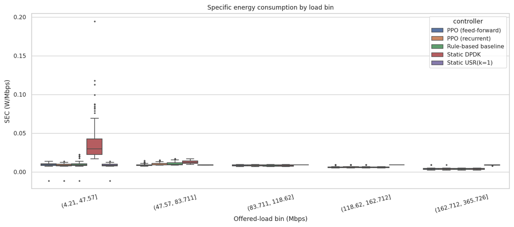

```
Saved: /home/ubuntu/EnergyAwareUPF/experiments/results/paper_results_assets/TODO_sec_by_load.pdf
```

```python
# ---- Figure: TODO_energy_time ----
fig, ax = plt.subplots(figsize=(11, 4.6), constrained_layout=True)
for name, g in timeline_df.groupby('controller'):
    ax.plot(g['t'], g['power'], linewidth=1.4, label=name)

ax.set_xlabel('Time step')
ax.set_ylabel('Power (W)')
ax.set_title('Interval-averaged power over test horizon')
ax.grid(True, linestyle='--', alpha=0.35)
ax.legend(ncol=2, frameon=True)

f_pdf = PAPER_OUT / 'TODO_energy_time.pdf'
f_png = PAPER_OUT / 'TODO_energy_time.png'
fig.savefig(f_pdf, bbox_inches='tight')
fig.savefig(f_png, bbox_inches='tight')
plt.show()
print('Saved:', f_pdf.resolve())

# ---- Figure: TODO_sec_by_load ----
plot_df = timeline_df.copy()
bin_edges = np.quantile(plot_df['traffic'].dropna(), [0, .2, .4, .6, .8, 1.0])
bin_edges = np.unique(bin_edges)
if len(bin_edges) < 3:
    bin_edges = np.linspace(plot_df['traffic'].min(), plot_df['traffic'].max(), 6)
plot_df['load_bin'] = pd.cut(plot_df['traffic'], bins=bin_edges, include_lowest=True)

fig2, ax2 = plt.subplots(figsize=(11, 4.8), constrained_layout=True)
sns.boxplot(data=plot_df, x='load_bin', y='sec', hue='controller', ax=ax2, fliersize=1.5)
ax2.set_xlabel('Offered-load bin (Mbps)')
ax2.set_ylabel('SEC (W/Mbps)')
ax2.set_title('Specific energy consumption by load bin')
ax2.tick_params(axis='x', rotation=15)

f2_pdf = PAPER_OUT / 'TODO_sec_by_load.pdf'
f2_png = PAPER_OUT / 'TODO_sec_by_load.png'
fig2.savefig(f2_pdf, bbox_inches='tight')
fig2.savefig(f2_png, bbox_inches='tight')
plt.show()
print('Saved:', f2_pdf.resolve())
```

[output not shown]

```
Saved: /home/ubuntu/EnergyAwareUPF/experiments/results/paper_results_assets/TODO_qos_time.pdf
```

```
Saved: /home/ubuntu/EnergyAwareUPF/experiments/results/paper_results_assets/TODO_qos_time.pdf
```

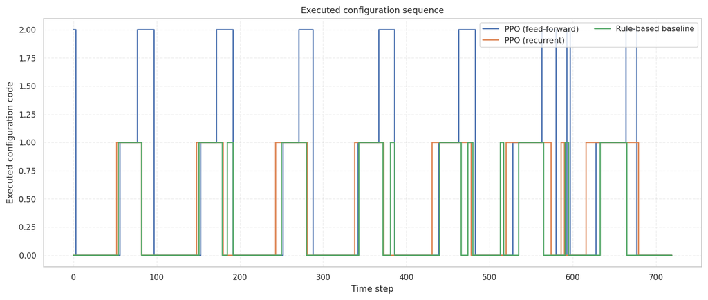

```
Saved: /home/ubuntu/EnergyAwareUPF/experiments/results/paper_results_assets/TODO_configs_time.pdf
```

```python
# ---- QoS and configuration figures ----
fig, ax = plt.subplots(figsize=(11, 4.6), constrained_layout=True)
for name, g in timeline_df.groupby('controller'):
    ax.plot(g['t'], g['qos'], linewidth=1.4, label=name)
ax.axhline(TAU, linestyle='--', color='black', linewidth=1.2, label=f'target={TAU:.2f}')
ax.set_xlabel('Time step')
ax.set_ylabel('QoS indicator')
ax.set_title('QoS compliance over test horizon')
ax.grid(True, linestyle='--', alpha=0.35)
ax.legend(ncol=2, frameon=True)

f_pdf = PAPER_OUT / 'TODO_qos_time.pdf'
f_png = PAPER_OUT / 'TODO_qos_time.png'
fig.savefig(f_pdf, bbox_inches='tight')
fig.savefig(f_png, bbox_inches='tight')
plt.show()
print('Saved:', f_pdf.resolve())

cfg_plot = timeline_df[timeline_df['controller'].isin(['PPO (feed-forward)', 'PPO (recurrent)', 'Rule-based baseline'])].copy()
fig2, ax2 = plt.subplots(figsize=(11, 4.6), constrained_layout=True)
for name, g in cfg_plot.groupby('controller'):
    ax2.step(g['t'], g['action'], where='post', linewidth=1.4, label=name)
ax2.set_xlabel('Time step')
ax2.set_ylabel('Executed configuration code')
ax2.set_title('Executed configuration sequence')
ax2.grid(True, linestyle='--', alpha=0.35)
ax2.legend(ncol=2, frameon=True)

f2_pdf = PAPER_OUT / 'TODO_configs_time.pdf'
f2_png = PAPER_OUT / 'TODO_configs_time.png'
fig2.savefig(f2_pdf, bbox_inches='tight')
fig2.savefig(f2_png, bbox_inches='tight')
plt.show()
print('Saved:', f2_pdf.resolve())
```

[output not shown]

|  | controller | n_reconf | blocked_frac |
| --- | --- | --- | --- |
| 0 | PPO (feed-forward) | 24 | 0.004167 |
| 2 | Rule-based baseline | 24 | 0.000000 |
| 1 | PPO (recurrent) | 16 | 0.009722 |
| 3 | Static DPDK | 0 | 0.000000 |
| 4 | Static USR(k=1) | 0 | 0.000000 |

|  | controller | n_reconf | blocked_frac |
| --- | --- | --- | --- |
| 0 | PPO (feed-forward) | 24 | 0.004167 |
| 2 | Rule-based baseline | 24 | 0.000000 |
| 1 | PPO (recurrent) | 16 | 0.009722 |
| 3 | Static DPDK | 0 | 0.000000 |
| 4 | Static USR(k=1) | 0 | 0.000000 |

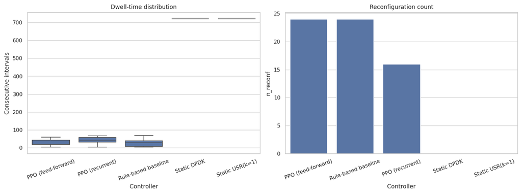

```
Saved: /home/ubuntu/EnergyAwareUPF/experiments/results/paper_results_assets/TODO_reconf_stats.pdf
```

```python
# ---- Figure: TODO_reconf_stats ----
stats_rows = []
dwell_rows = []
for name, g in timeline_df.groupby('controller'):
    n_reconf = _n_reconf(g['action'])
    blocked_frac = float(np.nanmean(g['blocked'])) if 'blocked' in g.columns else np.nan
    stats_rows.append({'controller': name, 'n_reconf': n_reconf, 'blocked_frac': blocked_frac})
    for d in _dwell_lengths(g['action']):
        dwell_rows.append({'controller': name, 'dwell': d})

reconf_stats = pd.DataFrame(stats_rows).sort_values('n_reconf', ascending=False)
dwell_df = pd.DataFrame(dwell_rows)
display(reconf_stats)

fig, axes = plt.subplots(1, 2, figsize=(12, 4.4), constrained_layout=True)
sns.boxplot(data=dwell_df, x='controller', y='dwell', ax=axes[0])
axes[0].set_title('Dwell-time distribution')
axes[0].set_xlabel('Controller')
axes[0].set_ylabel('Consecutive intervals')
axes[0].tick_params(axis='x', rotation=20)

sns.barplot(data=reconf_stats, x='controller', y='n_reconf', ax=axes[1], color='#4C72B0')
axes[1].set_title('Reconfiguration count')
axes[1].set_xlabel('Controller')
axes[1].set_ylabel('n_reconf')
axes[1].tick_params(axis='x', rotation=20)

f_pdf = PAPER_OUT / 'TODO_reconf_stats.pdf'
f_png = PAPER_OUT / 'TODO_reconf_stats.png'
fig.savefig(f_pdf, bbox_inches='tight')
fig.savefig(f_png, bbox_inches='tight')
plt.show()
print('Saved:', f_pdf.resolve())
```

```python
# ---- Table: ablation (tab:ablation_obs) ----
abl = a1_summary.copy()
abl['E_tot'] = pd.to_numeric(abl['total_power'], errors='coerce') * STEP_HOURS
abl['v'] = pd.to_numeric(abl['violation_rate'], errors='coerce')
abl['n_reconf'] = pd.to_numeric(abl['switch_dpdk_to_oai'], errors='coerce').fillna(0) + pd.to_numeric(abl['switch_oai_to_dpdk'], errors='coerce').fillna(0)

def policy_from_cfg(c):
    return 'Recurrent PPO' if str(c).startswith('lstm_') else 'PPO'

def obs_from_cfg(c):
    if 'instant' in c:
        return 'instantaneous'
    if 'history' in c:
        return 'history (W)'
    if 'forecast' in c:
        return 'forecast (H)'
    return 'hybrid'

abl['Policy'] = abl['config'].astype(str).map(policy_from_cfg)
abl['Observation schema'] = abl['config'].astype(str).map(obs_from_cfg)

# Keep only models not used in overall_results
overall_used_configs = {'mlp_hybrid', 'lstm_history'}
abl_tbl = abl[~abl['config'].isin(overall_used_configs)][['Policy', 'Observation schema', 'E_tot', 'v', 'n_reconf']].copy()

order_obs = ['instantaneous', 'history (W)', 'forecast (H)', 'hybrid']
abl_tbl['Observation schema'] = pd.Categorical(abl_tbl['Observation schema'], categories=order_obs, ordered=True)
abl_tbl = abl_tbl.sort_values(['Policy', 'Observation schema']).reset_index(drop=True)
display(abl_tbl.round({'E_tot': 2, 'v': 4}))

ablation_csv = PAPER_OUT / 'tab_ablation_obs.csv'
ablation_tex = PAPER_OUT / 'tab_ablation_obs.tex'
abl_tbl.to_csv(ablation_csv, index=False)
abl_tbl.to_latex(ablation_tex, index=False, float_format='%.6g')

print('Saved:', ablation_csv.resolve())
print('Saved:', ablation_tex.resolve())
```

|  | Policy | Observation schema | E_tot | v | n_reconf |
| --- | --- | --- | --- | --- | --- |
| 0 | PPO | instantaneous | 121.03 | 0.0014 | 24 |
| 1 | PPO | history (W) | 122.21 | 0.0014 | 19 |
| 2 | PPO | forecast (H) | 123.45 | 0.0014 | 15 |
| 3 | Recurrent PPO | instantaneous | 147.79 | 0.0000 | 0 |
| 4 | Recurrent PPO | forecast (H) | 147.79 | 0.0000 | 0 |
| 5 | Recurrent PPO | hybrid | 132.38 | 0.0042 | 14 |

|  | Policy | Observation schema | E_tot | v | n_reconf |
| --- | --- | --- | --- | --- | --- |
| 0 | PPO | instantaneous | 121.03 | 0.0014 | 24 |
| 1 | PPO | history (W) | 122.21 | 0.0014 | 19 |
| 2 | PPO | forecast (H) | 123.45 | 0.0014 | 15 |
| 3 | Recurrent PPO | instantaneous | 147.79 | 0.0000 | 0 |
| 4 | Recurrent PPO | forecast (H) | 147.79 | 0.0000 | 0 |
| 5 | Recurrent PPO | hybrid | 132.38 | 0.0042 | 14 |

```
Saved: /home/ubuntu/EnergyAwareUPF/experiments/results/paper_results_assets/tab_ablation_obs.csv
Saved: /home/ubuntu/EnergyAwareUPF/experiments/results/paper_results_assets/tab_ablation_obs.tex
```

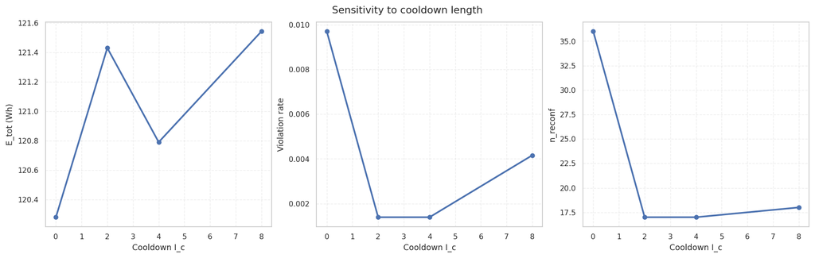

```
Saved: /home/ubuntu/EnergyAwareUPF/experiments/results/paper_results_assets/TODO_sensitivity_ic.pdf
```

```python
# ---- Figure: TODO_sensitivity_ic ----
sens = c1_cd.copy()
sens['cooldown'] = pd.to_numeric(sens['cooldown'], errors='coerce')
sens['E_tot'] = pd.to_numeric(sens['total_power'], errors='coerce') * STEP_HOURS
sens['v'] = pd.to_numeric(sens['violation_rate'], errors='coerce')
sens['n_reconf'] = pd.to_numeric(sens['switch_dpdk_to_oai'], errors='coerce') + pd.to_numeric(sens['switch_oai_to_dpdk'], errors='coerce')
sens = sens.sort_values('cooldown')

fig, axes = plt.subplots(1, 3, figsize=(13.5, 4.2), constrained_layout=True)
for ax, col, ylabel in [
    (axes[0], 'E_tot', 'E_tot (Wh)'),
    (axes[1], 'v', 'Violation rate'),
    (axes[2], 'n_reconf', 'n_reconf'),
]:
    ax.plot(sens['cooldown'], sens[col], marker='o', linewidth=2)
    ax.set_xlabel('Cooldown I_c')
    ax.set_ylabel(ylabel)
    ax.grid(True, linestyle='--', alpha=0.35)

fig.suptitle('Sensitivity to cooldown length')

f_pdf = PAPER_OUT / 'TODO_sensitivity_ic.pdf'
f_png = PAPER_OUT / 'TODO_sensitivity_ic.png'
fig.savefig(f_pdf, bbox_inches='tight')
fig.savefig(f_png, bbox_inches='tight')
plt.show()
print('Saved:', f_pdf.resolve())
```

```python
# ---- Auto-generated text snippets for Results writing ----
overall = tbl_overall.set_index('Controller')
ff = overall.loc['PPO (feed-forward)']
rec = overall.loc['PPO (recurrent)']
rule = overall.loc['Rule-based baseline']

delta_energy_rule = 100.0 * (rule['E_tot'] - ff['E_tot']) / max(rule['E_tot'], EPS)
delta_sec_rule = 100.0 * (rule['avg_SEC'] - ff['avg_SEC']) / max(rule['avg_SEC'], EPS)

snippet = f'''
Overall, PPO (feed-forward) achieves E_tot={ff['E_tot']:.2f} Wh, average SEC={ff['avg_SEC']:.5f}, v={ff['v']:.4f}, and n_reconf={int(ff['n_reconf'])}.
Compared with the rule-based baseline, this corresponds to {delta_energy_rule:.2f}% lower total energy and {delta_sec_rule:.2f}% lower average SEC at comparable violation rate.
The recurrent PPO variant reaches E_tot={rec['E_tot']:.2f} Wh with n_reconf={int(rec['n_reconf'])}, indicating a slightly more stable actuation profile.
'''.strip()

print(snippet)

snippet_txt = PAPER_OUT / 'results_text_snippets.txt'
snippet_txt.write_text(snippet + '\n', encoding='utf-8')
print('Saved:', snippet_txt.resolve())
```

```
Overall, PPO (feed-forward) achieves E_tot=120.79 Wh, average SEC=0.00735, v=0.0014, and n_reconf=17.
Compared with the rule-based baseline, this corresponds to 2.53% lower total energy and 5.17% lower average SEC at comparable violation rate.
The recurrent PPO variant reaches E_tot=125.74 Wh with n_reconf=16, indicating a slightly more stable actuation profile.
Saved: /home/ubuntu/EnergyAwareUPF/experiments/results/paper_results_assets/results_text_snippets.txt
```

|  | config | policy | k | tau | dpdk_share | oai_share | n_reconf |
| --- | --- | --- | --- | --- | --- | --- | --- |
| 0 | lstm_history_cd4_k1_t90 | lstm | 1 | 0.90 | 0.6458 | 0.3542 | 14 |
| 1 | lstm_history_cd4_k1_t95 | lstm | 1 | 0.95 | 0.7917 | 0.2083 | 14 |
| 2 | lstm_history_cd4_k2_t90 | lstm | 2 | 0.90 | 0.5792 | 0.4208 | 16 |
| 3 | lstm_history_cd4_k2_t95 | lstm | 2 | 0.95 | 0.7028 | 0.2972 | 16 |
| 4 | mlp_hybrid_cd4_k1_t90 | mlp | 1 | 0.90 | 0.5444 | 0.4556 | 20 |
| 5 | mlp_hybrid_cd4_k1_t95 | mlp | 1 | 0.95 | 0.7972 | 0.2028 | 12 |
| 6 | mlp_hybrid_cd4_k2_t90 | mlp | 2 | 0.90 | 0.5667 | 0.4333 | 24 |
| 7 | mlp_hybrid_cd4_k2_t95 | mlp | 2 | 0.95 | 0.6306 | 0.3694 | 19 |

|  | policy | tau | dpdk_share | oai_share | avg_oai_instances_when_oai | n_reconf | n_runs |
| --- | --- | --- | --- | --- | --- | --- | --- |
| 0 | lstm | 0.90 | 0.6125 | 0.3875 | 1.0000 | 15.0 | 2 |
| 1 | lstm | 0.95 | 0.7472 | 0.2528 | 1.0000 | 15.0 | 2 |
| 2 | mlp | 0.90 | 0.5556 | 0.4444 | 1.2131 | 22.0 | 2 |
| 3 | mlp | 0.95 | 0.7139 | 0.2861 | 1.0414 | 15.5 | 2 |

|  | config | policy | k | tau | dpdk_share | oai_share | n_reconf |
| --- | --- | --- | --- | --- | --- | --- | --- |
| 0 | lstm_history_cd4_k1_t90 | lstm | 1 | 0.90 | 0.6458 | 0.3542 | 14 |
| 1 | lstm_history_cd4_k1_t95 | lstm | 1 | 0.95 | 0.7917 | 0.2083 | 14 |
| 2 | lstm_history_cd4_k2_t90 | lstm | 2 | 0.90 | 0.5792 | 0.4208 | 16 |
| 3 | lstm_history_cd4_k2_t95 | lstm | 2 | 0.95 | 0.7028 | 0.2972 | 16 |
| 4 | mlp_hybrid_cd4_k1_t90 | mlp | 1 | 0.90 | 0.5444 | 0.4556 | 20 |
| 5 | mlp_hybrid_cd4_k1_t95 | mlp | 1 | 0.95 | 0.7972 | 0.2028 | 12 |
| 6 | mlp_hybrid_cd4_k2_t90 | mlp | 2 | 0.90 | 0.5667 | 0.4333 | 24 |
| 7 | mlp_hybrid_cd4_k2_t95 | mlp | 2 | 0.95 | 0.6306 | 0.3694 | 19 |

|  | policy | tau | dpdk_share | oai_share | avg_oai_instances_when_oai | n_reconf | n_runs |
| --- | --- | --- | --- | --- | --- | --- | --- |
| 0 | lstm | 0.90 | 0.6125 | 0.3875 | 1.0000 | 15.0 | 2 |
| 1 | lstm | 0.95 | 0.7472 | 0.2528 | 1.0000 | 15.0 | 2 |
| 2 | mlp | 0.90 | 0.5556 | 0.4444 | 1.2131 | 22.0 | 2 |
| 3 | mlp | 0.95 | 0.7139 | 0.2861 | 1.0414 | 15.5 | 2 |

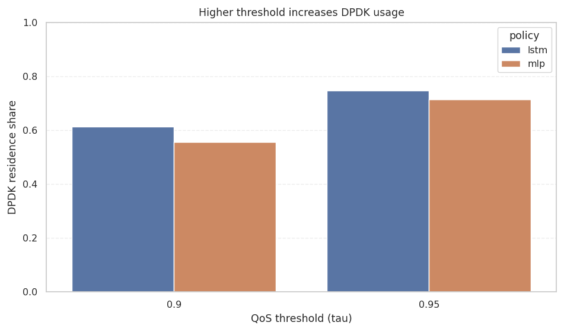

```
Threshold effect on DPDK share (tau=0.90 vs 0.95): lstm: 0.613 -> 0.747 (Δ=+13.5 pp); mlp: 0.556 -> 0.714 (Δ=+15.8 pp)
Saved: /home/ubuntu/EnergyAwareUPF/experiments/results/paper_results_assets/tab_threshold_dpdk_stickiness.csv
Saved: /home/ubuntu/EnergyAwareUPF/experiments/results/paper_results_assets/tab_threshold_dpdk_stickiness.tex
Saved: /home/ubuntu/EnergyAwareUPF/experiments/results/paper_results_assets/fig_threshold_dpdk_stickiness.pdf
Saved: /home/ubuntu/EnergyAwareUPF/experiments/results/paper_results_assets/threshold_effect_snippet.txt
```

```python
# ---- Threshold strictness analysis: does higher tau increase DPDK stickiness? ----
from collections import defaultdict

def _extract_ts(name: str) -> str:
    m = re.search(r'(\d{8}-\d{6})', name)
    return m.group(1) if m else ''

def _latest_eval_csv_per_run(root: Path) -> dict[Path, Path]:
    latest = {}
    for p in sorted(root.rglob('evaluation_results*.csv')):
        if p.parent.name != 'eval':
            continue
        run_dir = p.parent.parent
        if run_dir not in latest:
            latest[run_dir] = p
            continue
        old = latest[run_dir]
        t_new, t_old = _extract_ts(p.name), _extract_ts(old.name)
        if t_new and t_old:
            if t_new > t_old:
                latest[run_dir] = p
        elif p.stat().st_mtime > old.stat().st_mtime:
            latest[run_dir] = p
    return latest

def _parse_cfg_info(config_name: str):
    policy = 'lstm' if str(config_name).startswith('lstm') else 'mlp'
    km = re.search(r'_k(\d+)_', config_name)
    tm = re.search(r'_t(\d+)$', config_name)
    k = int(km.group(1)) if km else np.nan
    tau = (float(tm.group(1)) / 100.0) if tm else np.nan
    return policy, k, tau

latest_d1 = _latest_eval_csv_per_run(D1_ROOT)
rows_thr = []

for run_dir, eval_csv in latest_d1.items():
    config_name = run_dir.parent.name
    seed = run_dir.name
    policy, k, tau = _parse_cfg_info(config_name)

    df = pd.read_csv(eval_csv)
    df = _enforce_rl_720_steps(df)
    action = pd.to_numeric(df.get('executed_action', df.get('executed_code')), errors='coerce')
    valid = action.notna()
    if valid.sum() == 0:
        continue
    a = action[valid]
    dpdk_share = float((a == 0).mean())
    oai_share = float((a > 0).mean())
    avg_oai_instances = float(a[a > 0].mean()) if (a > 0).any() else 0.0
    n_reconf = int((a.diff().fillna(0) != 0).sum())

    rows_thr.append({
        'config': config_name,
        'seed': seed,
        'policy': policy,
        'k': k,
        'tau': tau,
        'steps_valid': int(valid.sum()),
        'dpdk_share': dpdk_share,
        'oai_share': oai_share,
        'avg_oai_instances_when_oai': avg_oai_instances,
        'n_reconf': n_reconf,
        'eval_csv': str(eval_csv),
    })

thr_df = pd.DataFrame(rows_thr).sort_values(['policy', 'k', 'tau']).reset_index(drop=True)
assert not thr_df.empty, 'No D1 threshold runs found.'

thr_summary = (
    thr_df.groupby(['policy', 'tau'], as_index=False)
    .agg(
        dpdk_share=('dpdk_share', 'mean'),
        oai_share=('oai_share', 'mean'),
        avg_oai_instances_when_oai=('avg_oai_instances_when_oai', 'mean'),
        n_reconf=('n_reconf', 'mean'),
        n_runs=('config', 'count'),
    )
    .sort_values(['policy', 'tau'])
    .reset_index(drop=True)
)

display(thr_df[['config', 'policy', 'k', 'tau', 'dpdk_share', 'oai_share', 'n_reconf']].round(4))
display(thr_summary.round(4))

thr_csv = PAPER_OUT / 'tab_threshold_dpdk_stickiness.csv'
thr_tex = PAPER_OUT / 'tab_threshold_dpdk_stickiness.tex'
thr_df.to_csv(thr_csv, index=False)
thr_summary.to_latex(thr_tex, index=False, float_format='%.6g')

fig, ax = plt.subplots(figsize=(7.2, 4.2), constrained_layout=True)
sns.barplot(data=thr_summary, x='tau', y='dpdk_share', hue='policy', ax=ax)
ax.set_xlabel('QoS threshold (tau)')
ax.set_ylabel('DPDK residence share')
ax.set_title('Higher threshold increases DPDK usage')
ax.set_ylim(0, 1)
ax.grid(axis='y', linestyle='--', alpha=0.35)

thr_fig_pdf = PAPER_OUT / 'fig_threshold_dpdk_stickiness.pdf'
thr_fig_png = PAPER_OUT / 'fig_threshold_dpdk_stickiness.png'
fig.savefig(thr_fig_pdf, bbox_inches='tight')
fig.savefig(thr_fig_png, bbox_inches='tight')
plt.show()

# Text snippet for paper
if set(thr_summary['tau'].dropna().unique()) >= {0.9, 0.95}:
    s90 = thr_summary[thr_summary['tau'] == 0.90].groupby('policy')['dpdk_share'].mean()
    s95 = thr_summary[thr_summary['tau'] == 0.95].groupby('policy')['dpdk_share'].mean()
    deltas = []
    for pol in sorted(set(s90.index) & set(s95.index)):
        delta = 100.0 * (s95[pol] - s90[pol])
        deltas.append(f"{pol}: {s90[pol]:.3f} -> {s95[pol]:.3f} (Δ={delta:+.1f} pp)")
    thr_snippet = 'Threshold effect on DPDK share (tau=0.90 vs 0.95): ' + '; '.join(deltas)
else:
    thr_snippet = 'Threshold comparison available, but one of tau=0.90/0.95 is missing.'

print(thr_snippet)
thr_txt = PAPER_OUT / 'threshold_effect_snippet.txt'
thr_txt.write_text(thr_snippet + '\n', encoding='utf-8')

print('Saved:', thr_csv.resolve())
print('Saved:', thr_tex.resolve())
print('Saved:', thr_fig_pdf.resolve())
print('Saved:', thr_txt.resolve())
```

## Resource and runtime reporting (D1)

For an ML/AI paper, the most useful systems metrics are:

- training wall-clock time and sample throughput (steps/s),
- CPU utilization (mean / p95),
- RAM footprint (mean / peak),
- GPU utilization and memory (if present),
- controller-side runtime energy (if measured by callback),
- inference latency per decision step (if explicitly logged).

The next cell computes all available metrics from `resource_usage.csv` and checks whether inference latency is available in evaluation traces.

|  | config | policy | k | tau | n_samples | train_elapsed_s | train_steps | train_steps_per_s | sample_period_s_median | cpu_pct_mean | cpu_pct_p95 | ram_gb_mean | ram_gb_peak | gpu_logged | gpu_util_pct_mean | gpu_mem_gb_peak | gpu_power_w_mean | cumulative_energy_wh_final |
| --- | --- | --- | --- | --- | --- | --- | --- | --- | --- | --- | --- | --- | --- | --- | --- | --- | --- | --- |
| 0 | lstm_history_cd4_k1_t90 | lstm | 1 | 0.90 | 303 | 692.5937 | 303000.0 | 437.4859 | 3.0407 | 3.3733 | 3.60 | 9.8083 | 9.8430 | False | NaN | NaN | NaN | 0.0 |
| 1 | lstm_history_cd4_k1_t95 | lstm | 1 | 0.95 | 303 | 683.4909 | 303000.0 | 443.3124 | 3.0309 | 3.3729 | 3.60 | 9.8438 | 9.8912 | False | NaN | NaN | NaN | 0.0 |
| 2 | lstm_history_cd4_k2_t90 | lstm | 2 | 0.90 | 303 | 687.8491 | 303000.0 | 440.5036 | 3.0686 | 3.3950 | 3.80 | 9.8494 | 9.9053 | False | NaN | NaN | NaN | 0.0 |
| 3 | lstm_history_cd4_k2_t95 | lstm | 2 | 0.95 | 303 | 689.0841 | 303000.0 | 439.7141 | 3.0390 | 3.4139 | 3.80 | 9.8403 | 9.9279 | False | NaN | NaN | NaN | 0.0 |
| 4 | mlp_hybrid_cd4_k1_t90 | mlp | 1 | 0.90 | 303 | 440.4189 | 303000.0 | 687.9814 | 1.8826 | 3.4132 | 3.90 | 9.7095 | 9.7979 | False | NaN | NaN | NaN | 0.0 |
| 5 | mlp_hybrid_cd4_k1_t95 | mlp | 1 | 0.95 | 303 | 437.3758 | 303000.0 | 692.7681 | 1.8040 | 3.3924 | 3.79 | 9.6828 | 9.7356 | False | NaN | NaN | NaN | 0.0 |
| 6 | mlp_hybrid_cd4_k2_t90 | mlp | 2 | 0.90 | 303 | 440.6562 | 303000.0 | 687.6109 | 1.8287 | 3.5871 | 4.50 | 9.6717 | 9.7352 | False | NaN | NaN | NaN | 0.0 |
| 7 | mlp_hybrid_cd4_k2_t95 | mlp | 2 | 0.95 | 303 | 442.0910 | 303000.0 | 685.3793 | 1.8220 | 3.4013 | 3.80 | 9.6785 | 9.7158 | False | NaN | NaN | NaN | 0.0 |

|  | policy | tau | train_elapsed_s | train_steps_per_s | cpu_pct_mean | cpu_pct_p95 | ram_gb_mean | ram_gb_peak | gpu_logged | cumulative_energy_wh_final | n_runs |
| --- | --- | --- | --- | --- | --- | --- | --- | --- | --- | --- | --- |
| 0 | lstm | 0.90 | 690.2214 | 438.9948 | 3.3842 | 3.700 | 9.8288 | 9.8741 | False | 0.0 | 2 |
| 1 | lstm | 0.95 | 686.2875 | 441.5132 | 3.3934 | 3.700 | 9.8421 | 9.9095 | False | 0.0 | 2 |
| 2 | mlp | 0.90 | 440.5375 | 687.7961 | 3.5002 | 4.200 | 9.6906 | 9.7666 | False | 0.0 | 2 |
| 3 | mlp | 0.95 | 439.7334 | 689.0737 | 3.3969 | 3.795 | 9.6806 | 9.7257 | False | 0.0 | 2 |

|  | config | policy | k | tau | n_samples | train_elapsed_s | train_steps | train_steps_per_s | sample_period_s_median | cpu_pct_mean | cpu_pct_p95 | ram_gb_mean | ram_gb_peak | gpu_logged | gpu_util_pct_mean | gpu_mem_gb_peak | gpu_power_w_mean | cumulative_energy_wh_final |
| --- | --- | --- | --- | --- | --- | --- | --- | --- | --- | --- | --- | --- | --- | --- | --- | --- | --- | --- |
| 0 | lstm_history_cd4_k1_t90 | lstm | 1 | 0.90 | 303 | 692.5937 | 303000.0 | 437.4859 | 3.0407 | 3.3733 | 3.60 | 9.8083 | 9.8430 | False | NaN | NaN | NaN | 0.0 |
| 1 | lstm_history_cd4_k1_t95 | lstm | 1 | 0.95 | 303 | 683.4909 | 303000.0 | 443.3124 | 3.0309 | 3.3729 | 3.60 | 9.8438 | 9.8912 | False | NaN | NaN | NaN | 0.0 |
| 2 | lstm_history_cd4_k2_t90 | lstm | 2 | 0.90 | 303 | 687.8491 | 303000.0 | 440.5036 | 3.0686 | 3.3950 | 3.80 | 9.8494 | 9.9053 | False | NaN | NaN | NaN | 0.0 |
| 3 | lstm_history_cd4_k2_t95 | lstm | 2 | 0.95 | 303 | 689.0841 | 303000.0 | 439.7141 | 3.0390 | 3.4139 | 3.80 | 9.8403 | 9.9279 | False | NaN | NaN | NaN | 0.0 |
| 4 | mlp_hybrid_cd4_k1_t90 | mlp | 1 | 0.90 | 303 | 440.4189 | 303000.0 | 687.9814 | 1.8826 | 3.4132 | 3.90 | 9.7095 | 9.7979 | False | NaN | NaN | NaN | 0.0 |
| 5 | mlp_hybrid_cd4_k1_t95 | mlp | 1 | 0.95 | 303 | 437.3758 | 303000.0 | 692.7681 | 1.8040 | 3.3924 | 3.79 | 9.6828 | 9.7356 | False | NaN | NaN | NaN | 0.0 |
| 6 | mlp_hybrid_cd4_k2_t90 | mlp | 2 | 0.90 | 303 | 440.6562 | 303000.0 | 687.6109 | 1.8287 | 3.5871 | 4.50 | 9.6717 | 9.7352 | False | NaN | NaN | NaN | 0.0 |
| 7 | mlp_hybrid_cd4_k2_t95 | mlp | 2 | 0.95 | 303 | 442.0910 | 303000.0 | 685.3793 | 1.8220 | 3.4013 | 3.80 | 9.6785 | 9.7158 | False | NaN | NaN | NaN | 0.0 |

|  | policy | tau | train_elapsed_s | train_steps_per_s | cpu_pct_mean | cpu_pct_p95 | ram_gb_mean | ram_gb_peak | gpu_logged | cumulative_energy_wh_final | n_runs |
| --- | --- | --- | --- | --- | --- | --- | --- | --- | --- | --- | --- |
| 0 | lstm | 0.90 | 690.2214 | 438.9948 | 3.3842 | 3.700 | 9.8288 | 9.8741 | False | 0.0 | 2 |
| 1 | lstm | 0.95 | 686.2875 | 441.5132 | 3.3934 | 3.700 | 9.8421 | 9.9095 | False | 0.0 | 2 |
| 2 | mlp | 0.90 | 440.5375 | 687.7961 | 3.5002 | 4.200 | 9.6906 | 9.7666 | False | 0.0 | 2 |
| 3 | mlp | 0.95 | 439.7334 | 689.0737 | 3.3969 | 3.795 | 9.6806 | 9.7257 | False | 0.0 | 2 |

```
Inference latency is not explicitly logged in current D1 eval/resource files. Recommendation: add per-step decision-time logging (ms) inside the policy inference path.
```

|  | config | policy | k | tau | n_samples | train_elapsed_s | train_steps | train_steps_per_s | sample_period_s_median | cpu_pct_mean | cpu_pct_p95 | ram_gb_mean | ram_gb_peak | gpu_logged | gpu_util_pct_mean | gpu_mem_gb_peak | gpu_power_w_mean | cumulative_energy_wh_final |
| --- | --- | --- | --- | --- | --- | --- | --- | --- | --- | --- | --- | --- | --- | --- | --- | --- | --- | --- |
| 0 | lstm_history_cd4_k1_t90 | lstm | 1 | 0.90 | 303 | 692.5937 | 303000.0 | 437.4859 | 3.0407 | 3.3733 | 3.60 | 9.8083 | 9.8430 | False | NaN | NaN | NaN | 0.0 |
| 1 | lstm_history_cd4_k1_t95 | lstm | 1 | 0.95 | 303 | 683.4909 | 303000.0 | 443.3124 | 3.0309 | 3.3729 | 3.60 | 9.8438 | 9.8912 | False | NaN | NaN | NaN | 0.0 |
| 2 | lstm_history_cd4_k2_t90 | lstm | 2 | 0.90 | 303 | 687.8491 | 303000.0 | 440.5036 | 3.0686 | 3.3950 | 3.80 | 9.8494 | 9.9053 | False | NaN | NaN | NaN | 0.0 |
| 3 | lstm_history_cd4_k2_t95 | lstm | 2 | 0.95 | 303 | 689.0841 | 303000.0 | 439.7141 | 3.0390 | 3.4139 | 3.80 | 9.8403 | 9.9279 | False | NaN | NaN | NaN | 0.0 |
| 4 | mlp_hybrid_cd4_k1_t90 | mlp | 1 | 0.90 | 303 | 440.4189 | 303000.0 | 687.9814 | 1.8826 | 3.4132 | 3.90 | 9.7095 | 9.7979 | False | NaN | NaN | NaN | 0.0 |
| 5 | mlp_hybrid_cd4_k1_t95 | mlp | 1 | 0.95 | 303 | 437.3758 | 303000.0 | 692.7681 | 1.8040 | 3.3924 | 3.79 | 9.6828 | 9.7356 | False | NaN | NaN | NaN | 0.0 |
| 6 | mlp_hybrid_cd4_k2_t90 | mlp | 2 | 0.90 | 303 | 440.6562 | 303000.0 | 687.6109 | 1.8287 | 3.5871 | 4.50 | 9.6717 | 9.7352 | False | NaN | NaN | NaN | 0.0 |
| 7 | mlp_hybrid_cd4_k2_t95 | mlp | 2 | 0.95 | 303 | 442.0910 | 303000.0 | 685.3793 | 1.8220 | 3.4013 | 3.80 | 9.6785 | 9.7158 | False | NaN | NaN | NaN | 0.0 |

|  | policy | tau | train_elapsed_s | train_steps_per_s | cpu_pct_mean | cpu_pct_p95 | ram_gb_mean | ram_gb_peak | gpu_logged | cumulative_energy_wh_final | n_runs |
| --- | --- | --- | --- | --- | --- | --- | --- | --- | --- | --- | --- |
| 0 | lstm | 0.90 | 690.2214 | 438.9948 | 3.3842 | 3.700 | 9.8288 | 9.8741 | False | 0.0 | 2 |
| 1 | lstm | 0.95 | 686.2875 | 441.5132 | 3.3934 | 3.700 | 9.8421 | 9.9095 | False | 0.0 | 2 |
| 2 | mlp | 0.90 | 440.5375 | 687.7961 | 3.5002 | 4.200 | 9.6906 | 9.7666 | False | 0.0 | 2 |
| 3 | mlp | 0.95 | 439.7334 | 689.0737 | 3.3969 | 3.795 | 9.6806 | 9.7257 | False | 0.0 | 2 |

```
Inference latency is not explicitly logged in current D1 eval/resource files. Recommendation: add per-step decision-time logging (ms) inside the policy inference path.
```

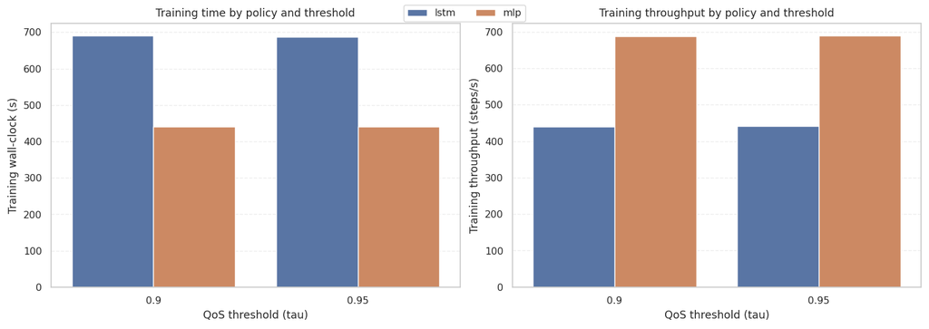

```
Saved: /home/ubuntu/EnergyAwareUPF/experiments/results/paper_results_assets/tab_d1_resource_runtime_per_run.csv
Saved: /home/ubuntu/EnergyAwareUPF/experiments/results/paper_results_assets/tab_d1_resource_runtime_summary.csv
Saved: /home/ubuntu/EnergyAwareUPF/experiments/results/paper_results_assets/tab_d1_resource_runtime_summary.tex
Saved: /home/ubuntu/EnergyAwareUPF/experiments/results/paper_results_assets/fig_d1_resource_runtime.pdf
Saved: /home/ubuntu/EnergyAwareUPF/experiments/results/paper_results_assets/resource_runtime_notes.txt
```

```python
# ---- D1 resource/runtime metrics from callback logs ----
resource_files = sorted(D1_ROOT.glob('*/seed_456/resource_usage.csv'))
assert resource_files, f'No resource_usage.csv found under {D1_ROOT}'

rows_res = []
for rf in resource_files:
    cfg = rf.parent.parent.name
    policy, k, tau = _parse_cfg_info(cfg)
    df = pd.read_csv(rf)
    if df.empty:
        continue

    elapsed = pd.to_numeric(df['elapsed_s'], errors='coerce')
    timesteps = pd.to_numeric(df['timesteps'], errors='coerce')
    cpu = pd.to_numeric(df['cpu_pct'], errors='coerce')
    ram = pd.to_numeric(df['ram_gb'], errors='coerce')

    final_elapsed = float(elapsed.iloc[-1]) if elapsed.notna().any() else np.nan
    final_steps = float(timesteps.iloc[-1]) if timesteps.notna().any() else np.nan
    steps_per_s = float(final_steps / final_elapsed) if final_elapsed and final_elapsed > 0 else np.nan

    # logging cadence (seconds between callback samples)
    dt = elapsed.diff().dropna()
    sample_period_s = float(dt.median()) if len(dt) > 0 else np.nan

    gpu_util = pd.to_numeric(df.get('gpu_util_pct'), errors='coerce') if 'gpu_util_pct' in df.columns else pd.Series([np.nan] * len(df))
    gpu_mem = pd.to_numeric(df.get('gpu_mem_gb'), errors='coerce') if 'gpu_mem_gb' in df.columns else pd.Series([np.nan] * len(df))
    gpu_power = pd.to_numeric(df.get('gpu_power_w'), errors='coerce') if 'gpu_power_w' in df.columns else pd.Series([np.nan] * len(df))
    cum_energy = pd.to_numeric(df.get('cumulative_energy_wh'), errors='coerce') if 'cumulative_energy_wh' in df.columns else pd.Series([np.nan] * len(df))

    rows_res.append({
        'config': cfg,
        'policy': policy,
        'k': k,
        'tau': tau,
        'n_samples': int(len(df)),
        'train_elapsed_s': final_elapsed,
        'train_steps': final_steps,
        'train_steps_per_s': steps_per_s,
        'sample_period_s_median': sample_period_s,
        'cpu_pct_mean': float(cpu.mean()),
        'cpu_pct_p95': float(cpu.quantile(0.95)),
        'ram_gb_mean': float(ram.mean()),
        'ram_gb_peak': float(ram.max()),
        'gpu_logged': bool(gpu_util.notna().any() or gpu_mem.notna().any() or gpu_power.notna().any()),
        'gpu_util_pct_mean': float(gpu_util.mean()) if gpu_util.notna().any() else np.nan,
        'gpu_mem_gb_peak': float(gpu_mem.max()) if gpu_mem.notna().any() else np.nan,
        'gpu_power_w_mean': float(gpu_power.mean()) if gpu_power.notna().any() else np.nan,
        'cumulative_energy_wh_final': float(cum_energy.iloc[-1]) if cum_energy.notna().any() else np.nan,
    })

res_df = pd.DataFrame(rows_res).sort_values(['policy', 'k', 'tau']).reset_index(drop=True)
display(res_df.round(4))

res_summary = (
    res_df.groupby(['policy', 'tau'], as_index=False)
    .agg(
        train_elapsed_s=('train_elapsed_s', 'mean'),
        train_steps_per_s=('train_steps_per_s', 'mean'),
        cpu_pct_mean=('cpu_pct_mean', 'mean'),
        cpu_pct_p95=('cpu_pct_p95', 'mean'),
        ram_gb_mean=('ram_gb_mean', 'mean'),
        ram_gb_peak=('ram_gb_peak', 'mean'),
        gpu_logged=('gpu_logged', 'max'),
        cumulative_energy_wh_final=('cumulative_energy_wh_final', 'mean'),
        n_runs=('config', 'count'),
    )
    .sort_values(['policy', 'tau'])
    .reset_index(drop=True)
)
display(res_summary.round(4))

# Check whether inference latency exists in eval traces
candidate_latency_cols = {'inference_ms', 'inference_time_ms', 'decision_time_ms', 'policy_time_ms', 'latency_ms'}
eval_has_latency = []
for _, r in thr_df.iterrows():
    ep = Path(r['eval_csv'])
    if not ep.exists():
        ep = (Path.cwd() / ep).resolve()
    try:
        edf = pd.read_csv(ep, nrows=1)
        found = sorted(set(edf.columns).intersection(candidate_latency_cols))
        eval_has_latency.append((r['config'], found))
    except Exception:
        eval_has_latency.append((r['config'], []))

latency_available = any(len(cols) > 0 for _, cols in eval_has_latency)
if latency_available:
    latency_note = 'Inference latency columns found: ' + str([x for x in eval_has_latency if x[1]])
else:
    latency_note = (
        'Inference latency is not explicitly logged in current D1 eval/resource files. '
        'Recommendation: add per-step decision-time logging (ms) inside the policy inference path.'
    )
print(latency_note)

# Export
res_csv = PAPER_OUT / 'tab_d1_resource_runtime_per_run.csv'
res_sum_csv = PAPER_OUT / 'tab_d1_resource_runtime_summary.csv'
res_sum_tex = PAPER_OUT / 'tab_d1_resource_runtime_summary.tex'
res_note_txt = PAPER_OUT / 'resource_runtime_notes.txt'

res_df.to_csv(res_csv, index=False)
res_summary.to_csv(res_sum_csv, index=False)
res_summary.to_latex(res_sum_tex, index=False, float_format='%.6g')
res_note_txt.write_text(latency_note + '\n', encoding='utf-8')

# Figure
fig, axes = plt.subplots(1, 2, figsize=(11.5, 4.0), constrained_layout=True)
sns.barplot(data=res_summary, x='tau', y='train_elapsed_s', hue='policy', ax=axes[0])
axes[0].set_xlabel('QoS threshold (tau)')
axes[0].set_ylabel('Training wall-clock (s)')
axes[0].set_title('Training time by policy and threshold')
axes[0].grid(axis='y', linestyle='--', alpha=0.35)

sns.barplot(data=res_summary, x='tau', y='train_steps_per_s', hue='policy', ax=axes[1])
axes[1].set_xlabel('QoS threshold (tau)')
axes[1].set_ylabel('Training throughput (steps/s)')
axes[1].set_title('Training throughput by policy and threshold')
axes[1].grid(axis='y', linestyle='--', alpha=0.35)

# unify legends
h0, l0 = axes[0].get_legend_handles_labels()
for ax in axes:
    lg = ax.get_legend()
    if lg:
        lg.remove()
fig.legend(h0, l0, loc='upper center', ncol=2, frameon=True)

res_fig_pdf = PAPER_OUT / 'fig_d1_resource_runtime.pdf'
res_fig_png = PAPER_OUT / 'fig_d1_resource_runtime.png'
fig.savefig(res_fig_pdf, bbox_inches='tight')
fig.savefig(res_fig_png, bbox_inches='tight')
plt.show()

print('Saved:', res_csv.resolve())
print('Saved:', res_sum_csv.resolve())
print('Saved:', res_sum_tex.resolve())
print('Saved:', res_fig_pdf.resolve())
print('Saved:', res_note_txt.resolve())
```

## TensorBoard-derived systems metrics (D1)

TensorBoard logging is available and useful for systems reporting. The next cell extracts:

- `time/fps` (training throughput),
- `sys/cpu_pct` and `sys/ram_gb`,
- final training timesteps from `train/timesteps`,
- presence/absence of latency-related tags (`latency`, `inference`, `decision_time`).

|  | config | policy | k | tau | tb_time_fps_last | tb_time_fps_mean | tb_cpu_pct_mean | tb_cpu_pct_p95 | tb_ram_gb_mean | tb_ram_gb_p95 | tb_train_timesteps_last | tb_train_ep_return_last | tb_train_ep_return_mean | tb_eval_mean_reward_last | tb_eval_mean_ep_length_last |
| --- | --- | --- | --- | --- | --- | --- | --- | --- | --- | --- | --- | --- | --- | --- | --- |
| 0 | lstm_history_cd4_k1_t90 | lstm | 1 | 0.90 | 437.0 | 437.8649 | 3.3737 | 3.700 | 9.8080 | 9.8355 | 301184.0 | -1749.3495 | -1829.1233 | -552.4946 | 721.0 |
| 1 | lstm_history_cd4_k1_t95 | lstm | 1 | 0.95 | 443.0 | 440.1216 | 3.3835 | 3.700 | 9.8448 | 9.8713 | 301184.0 | -2270.7056 | -2389.1091 | -699.0650 | 721.0 |
| 2 | lstm_history_cd4_k2_t90 | lstm | 2 | 0.90 | 440.0 | 435.6081 | 3.3938 | 3.900 | 9.8494 | 9.8766 | 301184.0 | -1761.0066 | -1844.5097 | -596.8653 | 721.0 |
| 3 | lstm_history_cd4_k2_t95 | lstm | 2 | 0.95 | 439.0 | 438.9324 | 3.4180 | 3.900 | 9.8411 | 9.9072 | 301184.0 | -2211.4995 | -2582.5530 | -816.3481 | 721.0 |
| 4 | mlp_hybrid_cd4_k1_t90 | mlp | 1 | 0.90 | 688.0 | 695.1081 | 3.4253 | 4.035 | 9.7094 | 9.7707 | 301184.0 | -1690.4849 | -1856.9540 | -552.6417 | 721.0 |
| 5 | mlp_hybrid_cd4_k1_t95 | mlp | 1 | 0.95 | 692.0 | 705.9865 | 3.3959 | 3.835 | 9.6834 | 9.7196 | 301184.0 | -2125.2302 | -2285.3194 | -929.1058 | 721.0 |
| 6 | mlp_hybrid_cd4_k2_t90 | mlp | 2 | 0.90 | 687.0 | 697.3784 | 3.6129 | 4.800 | 9.6716 | 9.7086 | 301184.0 | -1752.7223 | -1836.0043 | -975.4014 | 721.0 |
| 7 | mlp_hybrid_cd4_k2_t95 | mlp | 2 | 0.95 | 685.0 | 696.6216 | 3.4046 | 3.900 | 9.6784 | 9.6991 | 301184.0 | -2503.7251 | -2576.2228 | -975.5027 | 721.0 |

|  | config | policy | k | tau | tb_time_fps_last | tb_time_fps_mean | tb_cpu_pct_mean | tb_cpu_pct_p95 | tb_ram_gb_mean | tb_ram_gb_p95 | tb_train_timesteps_last | tb_train_ep_return_last | tb_train_ep_return_mean | tb_eval_mean_reward_last | tb_eval_mean_ep_length_last |
| --- | --- | --- | --- | --- | --- | --- | --- | --- | --- | --- | --- | --- | --- | --- | --- |
| 0 | lstm_history_cd4_k1_t90 | lstm | 1 | 0.90 | 437.0 | 437.8649 | 3.3737 | 3.700 | 9.8080 | 9.8355 | 301184.0 | -1749.3495 | -1829.1233 | -552.4946 | 721.0 |
| 1 | lstm_history_cd4_k1_t95 | lstm | 1 | 0.95 | 443.0 | 440.1216 | 3.3835 | 3.700 | 9.8448 | 9.8713 | 301184.0 | -2270.7056 | -2389.1091 | -699.0650 | 721.0 |
| 2 | lstm_history_cd4_k2_t90 | lstm | 2 | 0.90 | 440.0 | 435.6081 | 3.3938 | 3.900 | 9.8494 | 9.8766 | 301184.0 | -1761.0066 | -1844.5097 | -596.8653 | 721.0 |
| 3 | lstm_history_cd4_k2_t95 | lstm | 2 | 0.95 | 439.0 | 438.9324 | 3.4180 | 3.900 | 9.8411 | 9.9072 | 301184.0 | -2211.4995 | -2582.5530 | -816.3481 | 721.0 |
| 4 | mlp_hybrid_cd4_k1_t90 | mlp | 1 | 0.90 | 688.0 | 695.1081 | 3.4253 | 4.035 | 9.7094 | 9.7707 | 301184.0 | -1690.4849 | -1856.9540 | -552.6417 | 721.0 |
| 5 | mlp_hybrid_cd4_k1_t95 | mlp | 1 | 0.95 | 692.0 | 705.9865 | 3.3959 | 3.835 | 9.6834 | 9.7196 | 301184.0 | -2125.2302 | -2285.3194 | -929.1058 | 721.0 |
| 6 | mlp_hybrid_cd4_k2_t90 | mlp | 2 | 0.90 | 687.0 | 697.3784 | 3.6129 | 4.800 | 9.6716 | 9.7086 | 301184.0 | -1752.7223 | -1836.0043 | -975.4014 | 721.0 |
| 7 | mlp_hybrid_cd4_k2_t95 | mlp | 2 | 0.95 | 685.0 | 696.6216 | 3.4046 | 3.900 | 9.6784 | 9.6991 | 301184.0 | -2503.7251 | -2576.2228 | -975.5027 | 721.0 |

|  | policy | tau | tb_time_fps_last | tb_time_fps_mean | tb_cpu_pct_mean | tb_cpu_pct_p95 | tb_ram_gb_mean | tb_ram_gb_p95 | tb_train_timesteps_last | tb_train_ep_return_last | tb_train_ep_return_mean | tb_eval_mean_reward_last | n_runs |
| --- | --- | --- | --- | --- | --- | --- | --- | --- | --- | --- | --- | --- | --- |
| 0 | lstm | 0.90 | 438.5 | 436.7365 | 3.3838 | 3.8000 | 9.8287 | 9.8560 | 301184.0 | -1755.1780 | -1836.8165 | -574.6799 | 2 |
| 1 | lstm | 0.95 | 441.0 | 439.5270 | 3.4008 | 3.8000 | 9.8429 | 9.8892 | 301184.0 | -2241.1025 | -2485.8311 | -757.7066 | 2 |
| 2 | mlp | 0.90 | 687.5 | 696.2432 | 3.5191 | 4.4175 | 9.6905 | 9.7396 | 301184.0 | -1721.6036 | -1846.4791 | -764.0215 | 2 |
| 3 | mlp | 0.95 | 688.5 | 701.3041 | 3.4003 | 3.8675 | 9.6809 | 9.7093 | 301184.0 | -2314.4777 | -2430.7711 | -952.3043 | 2 |

|  | config | policy | k | tau | tb_time_fps_last | tb_time_fps_mean | tb_cpu_pct_mean | tb_cpu_pct_p95 | tb_ram_gb_mean | tb_ram_gb_p95 | tb_train_timesteps_last | tb_train_ep_return_last | tb_train_ep_return_mean | tb_eval_mean_reward_last | tb_eval_mean_ep_length_last |
| --- | --- | --- | --- | --- | --- | --- | --- | --- | --- | --- | --- | --- | --- | --- | --- |
| 0 | lstm_history_cd4_k1_t90 | lstm | 1 | 0.90 | 437.0 | 437.8649 | 3.3737 | 3.700 | 9.8080 | 9.8355 | 301184.0 | -1749.3495 | -1829.1233 | -552.4946 | 721.0 |
| 1 | lstm_history_cd4_k1_t95 | lstm | 1 | 0.95 | 443.0 | 440.1216 | 3.3835 | 3.700 | 9.8448 | 9.8713 | 301184.0 | -2270.7056 | -2389.1091 | -699.0650 | 721.0 |
| 2 | lstm_history_cd4_k2_t90 | lstm | 2 | 0.90 | 440.0 | 435.6081 | 3.3938 | 3.900 | 9.8494 | 9.8766 | 301184.0 | -1761.0066 | -1844.5097 | -596.8653 | 721.0 |
| 3 | lstm_history_cd4_k2_t95 | lstm | 2 | 0.95 | 439.0 | 438.9324 | 3.4180 | 3.900 | 9.8411 | 9.9072 | 301184.0 | -2211.4995 | -2582.5530 | -816.3481 | 721.0 |
| 4 | mlp_hybrid_cd4_k1_t90 | mlp | 1 | 0.90 | 688.0 | 695.1081 | 3.4253 | 4.035 | 9.7094 | 9.7707 | 301184.0 | -1690.4849 | -1856.9540 | -552.6417 | 721.0 |
| 5 | mlp_hybrid_cd4_k1_t95 | mlp | 1 | 0.95 | 692.0 | 705.9865 | 3.3959 | 3.835 | 9.6834 | 9.7196 | 301184.0 | -2125.2302 | -2285.3194 | -929.1058 | 721.0 |
| 6 | mlp_hybrid_cd4_k2_t90 | mlp | 2 | 0.90 | 687.0 | 697.3784 | 3.6129 | 4.800 | 9.6716 | 9.7086 | 301184.0 | -1752.7223 | -1836.0043 | -975.4014 | 721.0 |
| 7 | mlp_hybrid_cd4_k2_t95 | mlp | 2 | 0.95 | 685.0 | 696.6216 | 3.4046 | 3.900 | 9.6784 | 9.6991 | 301184.0 | -2503.7251 | -2576.2228 | -975.5027 | 721.0 |

|  | policy | tau | tb_time_fps_last | tb_time_fps_mean | tb_cpu_pct_mean | tb_cpu_pct_p95 | tb_ram_gb_mean | tb_ram_gb_p95 | tb_train_timesteps_last | tb_train_ep_return_last | tb_train_ep_return_mean | tb_eval_mean_reward_last | n_runs |
| --- | --- | --- | --- | --- | --- | --- | --- | --- | --- | --- | --- | --- | --- |
| 0 | lstm | 0.90 | 438.5 | 436.7365 | 3.3838 | 3.8000 | 9.8287 | 9.8560 | 301184.0 | -1755.1780 | -1836.8165 | -574.6799 | 2 |
| 1 | lstm | 0.95 | 441.0 | 439.5270 | 3.4008 | 3.8000 | 9.8429 | 9.8892 | 301184.0 | -2241.1025 | -2485.8311 | -757.7066 | 2 |
| 2 | mlp | 0.90 | 687.5 | 696.2432 | 3.5191 | 4.4175 | 9.6905 | 9.7396 | 301184.0 | -1721.6036 | -1846.4791 | -764.0215 | 2 |
| 3 | mlp | 0.95 | 688.5 | 701.3041 | 3.4003 | 3.8675 | 9.6809 | 9.7093 | 301184.0 | -2314.4777 | -2430.7711 | -952.3043 | 2 |

```
No GPU-related TensorBoard scalar tags found in current D1 runs. No latency/inference/decision-time tags found in TensorBoard scalars.
```

|  | config | policy | k | tau | tb_time_fps_last | tb_time_fps_mean | tb_cpu_pct_mean | tb_cpu_pct_p95 | tb_ram_gb_mean | tb_ram_gb_p95 | tb_train_timesteps_last | tb_train_ep_return_last | tb_train_ep_return_mean | tb_eval_mean_reward_last | tb_eval_mean_ep_length_last |
| --- | --- | --- | --- | --- | --- | --- | --- | --- | --- | --- | --- | --- | --- | --- | --- |
| 0 | lstm_history_cd4_k1_t90 | lstm | 1 | 0.90 | 437.0 | 437.8649 | 3.3737 | 3.700 | 9.8080 | 9.8355 | 301184.0 | -1749.3495 | -1829.1233 | -552.4946 | 721.0 |
| 1 | lstm_history_cd4_k1_t95 | lstm | 1 | 0.95 | 443.0 | 440.1216 | 3.3835 | 3.700 | 9.8448 | 9.8713 | 301184.0 | -2270.7056 | -2389.1091 | -699.0650 | 721.0 |
| 2 | lstm_history_cd4_k2_t90 | lstm | 2 | 0.90 | 440.0 | 435.6081 | 3.3938 | 3.900 | 9.8494 | 9.8766 | 301184.0 | -1761.0066 | -1844.5097 | -596.8653 | 721.0 |
| 3 | lstm_history_cd4_k2_t95 | lstm | 2 | 0.95 | 439.0 | 438.9324 | 3.4180 | 3.900 | 9.8411 | 9.9072 | 301184.0 | -2211.4995 | -2582.5530 | -816.3481 | 721.0 |
| 4 | mlp_hybrid_cd4_k1_t90 | mlp | 1 | 0.90 | 688.0 | 695.1081 | 3.4253 | 4.035 | 9.7094 | 9.7707 | 301184.0 | -1690.4849 | -1856.9540 | -552.6417 | 721.0 |
| 5 | mlp_hybrid_cd4_k1_t95 | mlp | 1 | 0.95 | 692.0 | 705.9865 | 3.3959 | 3.835 | 9.6834 | 9.7196 | 301184.0 | -2125.2302 | -2285.3194 | -929.1058 | 721.0 |
| 6 | mlp_hybrid_cd4_k2_t90 | mlp | 2 | 0.90 | 687.0 | 697.3784 | 3.6129 | 4.800 | 9.6716 | 9.7086 | 301184.0 | -1752.7223 | -1836.0043 | -975.4014 | 721.0 |
| 7 | mlp_hybrid_cd4_k2_t95 | mlp | 2 | 0.95 | 685.0 | 696.6216 | 3.4046 | 3.900 | 9.6784 | 9.6991 | 301184.0 | -2503.7251 | -2576.2228 | -975.5027 | 721.0 |

|  | policy | tau | tb_time_fps_last | tb_time_fps_mean | tb_cpu_pct_mean | tb_cpu_pct_p95 | tb_ram_gb_mean | tb_ram_gb_p95 | tb_train_timesteps_last | tb_train_ep_return_last | tb_train_ep_return_mean | tb_eval_mean_reward_last | n_runs |
| --- | --- | --- | --- | --- | --- | --- | --- | --- | --- | --- | --- | --- | --- |
| 0 | lstm | 0.90 | 438.5 | 436.7365 | 3.3838 | 3.8000 | 9.8287 | 9.8560 | 301184.0 | -1755.1780 | -1836.8165 | -574.6799 | 2 |
| 1 | lstm | 0.95 | 441.0 | 439.5270 | 3.4008 | 3.8000 | 9.8429 | 9.8892 | 301184.0 | -2241.1025 | -2485.8311 | -757.7066 | 2 |
| 2 | mlp | 0.90 | 687.5 | 696.2432 | 3.5191 | 4.4175 | 9.6905 | 9.7396 | 301184.0 | -1721.6036 | -1846.4791 | -764.0215 | 2 |
| 3 | mlp | 0.95 | 688.5 | 701.3041 | 3.4003 | 3.8675 | 9.6809 | 9.7093 | 301184.0 | -2314.4777 | -2430.7711 | -952.3043 | 2 |

```
No GPU-related TensorBoard scalar tags found in current D1 runs. No latency/inference/decision-time tags found in TensorBoard scalars.
```

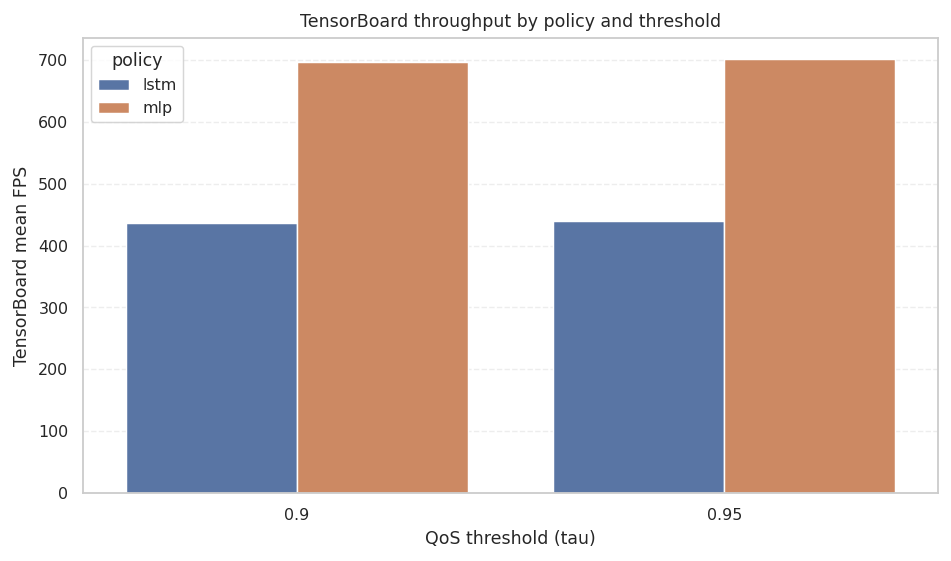

|  | config | policy | k | tau | tb_time_fps_last | tb_time_fps_mean | tb_cpu_pct_mean | tb_cpu_pct_p95 | tb_ram_gb_mean | tb_ram_gb_p95 | tb_train_timesteps_last | tb_train_ep_return_last | tb_train_ep_return_mean | tb_eval_mean_reward_last | tb_eval_mean_ep_length_last |
| --- | --- | --- | --- | --- | --- | --- | --- | --- | --- | --- | --- | --- | --- | --- | --- |
| 0 | lstm_history_cd4_k1_t90 | lstm | 1 | 0.90 | 437.0 | 437.8649 | 3.3737 | 3.700 | 9.8080 | 9.8355 | 301184.0 | -1749.3495 | -1829.1233 | -552.4946 | 721.0 |
| 1 | lstm_history_cd4_k1_t95 | lstm | 1 | 0.95 | 443.0 | 440.1216 | 3.3835 | 3.700 | 9.8448 | 9.8713 | 301184.0 | -2270.7056 | -2389.1091 | -699.0650 | 721.0 |
| 2 | lstm_history_cd4_k2_t90 | lstm | 2 | 0.90 | 440.0 | 435.6081 | 3.3938 | 3.900 | 9.8494 | 9.8766 | 301184.0 | -1761.0066 | -1844.5097 | -596.8653 | 721.0 |
| 3 | lstm_history_cd4_k2_t95 | lstm | 2 | 0.95 | 439.0 | 438.9324 | 3.4180 | 3.900 | 9.8411 | 9.9072 | 301184.0 | -2211.4995 | -2582.5530 | -816.3481 | 721.0 |
| 4 | mlp_hybrid_cd4_k1_t90 | mlp | 1 | 0.90 | 688.0 | 695.1081 | 3.4253 | 4.035 | 9.7094 | 9.7707 | 301184.0 | -1690.4849 | -1856.9540 | -552.6417 | 721.0 |
| 5 | mlp_hybrid_cd4_k1_t95 | mlp | 1 | 0.95 | 692.0 | 705.9865 | 3.3959 | 3.835 | 9.6834 | 9.7196 | 301184.0 | -2125.2302 | -2285.3194 | -929.1058 | 721.0 |
| 6 | mlp_hybrid_cd4_k2_t90 | mlp | 2 | 0.90 | 687.0 | 697.3784 | 3.6129 | 4.800 | 9.6716 | 9.7086 | 301184.0 | -1752.7223 | -1836.0043 | -975.4014 | 721.0 |
| 7 | mlp_hybrid_cd4_k2_t95 | mlp | 2 | 0.95 | 685.0 | 696.6216 | 3.4046 | 3.900 | 9.6784 | 9.6991 | 301184.0 | -2503.7251 | -2576.2228 | -975.5027 | 721.0 |

|  | policy | tau | tb_time_fps_last | tb_time_fps_mean | tb_cpu_pct_mean | tb_cpu_pct_p95 | tb_ram_gb_mean | tb_ram_gb_p95 | tb_train_timesteps_last | tb_train_ep_return_last | tb_train_ep_return_mean | tb_eval_mean_reward_last | n_runs |
| --- | --- | --- | --- | --- | --- | --- | --- | --- | --- | --- | --- | --- | --- |
| 0 | lstm | 0.90 | 438.5 | 436.7365 | 3.3838 | 3.8000 | 9.8287 | 9.8560 | 301184.0 | -1755.1780 | -1836.8165 | -574.6799 | 2 |
| 1 | lstm | 0.95 | 441.0 | 439.5270 | 3.4008 | 3.8000 | 9.8429 | 9.8892 | 301184.0 | -2241.1025 | -2485.8311 | -757.7066 | 2 |
| 2 | mlp | 0.90 | 687.5 | 696.2432 | 3.5191 | 4.4175 | 9.6905 | 9.7396 | 301184.0 | -1721.6036 | -1846.4791 | -764.0215 | 2 |
| 3 | mlp | 0.95 | 688.5 | 701.3041 | 3.4003 | 3.8675 | 9.6809 | 9.7093 | 301184.0 | -2314.4777 | -2430.7711 | -952.3043 | 2 |

```
No GPU-related TensorBoard scalar tags found in current D1 runs. No latency/inference/decision-time tags found in TensorBoard scalars.
```

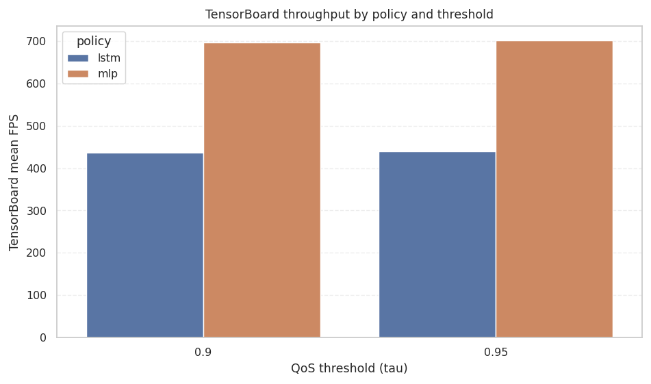

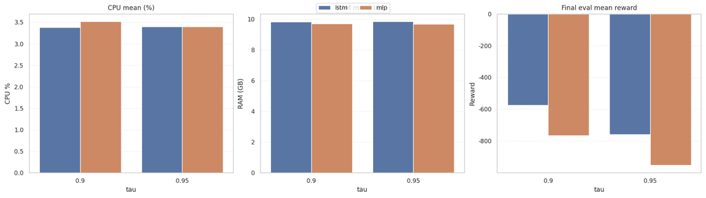

```
Saved: /home/ubuntu/EnergyAwareUPF/experiments/results/paper_results_assets/tab_d1_tensorboard_metrics_per_run.csv
Saved: /home/ubuntu/EnergyAwareUPF/experiments/results/paper_results_assets/tab_d1_tensorboard_metrics_summary.csv
Saved: /home/ubuntu/EnergyAwareUPF/experiments/results/paper_results_assets/tab_d1_tensorboard_metrics_summary.tex
Saved: /home/ubuntu/EnergyAwareUPF/experiments/results/paper_results_assets/fig_d1_tensorboard_fps.pdf
Saved: /home/ubuntu/EnergyAwareUPF/experiments/results/paper_results_assets/fig_d1_tensorboard_cpu_ram_reward.pdf
Saved: /home/ubuntu/EnergyAwareUPF/experiments/results/paper_results_assets/tensorboard_runtime_notes.txt
```

```python
# ---- Parse TensorBoard event files for D1 systems metrics ----
from tensorboard.backend.event_processing.event_accumulator import EventAccumulator

tb_event_files = sorted(D1_ROOT.glob('*/seed_456/tb_logs/*/*/events.out.tfevents.*'))
assert tb_event_files, f'No TensorBoard event files found under {D1_ROOT}'

def _safe_scalar_last(ea: EventAccumulator, tag: str):
    vals = ea.Scalars(tag) if tag in ea.Tags().get('scalars', []) else []
    return float(vals[-1].value) if vals else np.nan

def _safe_scalar_mean(ea: EventAccumulator, tag: str):
    vals = ea.Scalars(tag) if tag in ea.Tags().get('scalars', []) else []
    return float(np.mean([v.value for v in vals])) if vals else np.nan

def _safe_scalar_p95(ea: EventAccumulator, tag: str):
    vals = ea.Scalars(tag) if tag in ea.Tags().get('scalars', []) else []
    return float(np.quantile([v.value for v in vals], 0.95)) if vals else np.nan

rows_tb = []
all_tags_union = set()

for ev in tb_event_files:
    # .../<config>/seed_456/tb_logs/<timestamp>/<algo>/events.out.tfevents.*
    cfg = ev.parents[4].name
    policy = 'lstm' if cfg.startswith('lstm') else 'mlp'
    km = re.search(r'_k(\d+)_', cfg)
    tm = re.search(r'_t(\d+)$', cfg)
    k = int(km.group(1)) if km else np.nan
    tau = float(tm.group(1)) / 100.0 if tm else np.nan

    ea = EventAccumulator(str(ev))
    ea.Reload()
    tags = set(ea.Tags().get('scalars', []))
    all_tags_union.update(tags)

    rows_tb.append({
        'config': cfg,
        'policy': policy,
        'k': k,
        'tau': tau,
        'tb_time_fps_last': _safe_scalar_last(ea, 'time/fps'),
        'tb_time_fps_mean': _safe_scalar_mean(ea, 'time/fps'),
        'tb_cpu_pct_mean': _safe_scalar_mean(ea, 'sys/cpu_pct'),
        'tb_cpu_pct_p95': _safe_scalar_p95(ea, 'sys/cpu_pct'),
        'tb_ram_gb_mean': _safe_scalar_mean(ea, 'sys/ram_gb'),
        'tb_ram_gb_p95': _safe_scalar_p95(ea, 'sys/ram_gb'),
        'tb_train_timesteps_last': _safe_scalar_last(ea, 'train/timesteps'),
        'tb_train_ep_return_last': _safe_scalar_last(ea, 'train/ep_return'),
        'tb_train_ep_return_mean': _safe_scalar_mean(ea, 'train/ep_return'),
        'tb_eval_mean_reward_last': _safe_scalar_last(ea, 'eval/mean_reward'),
        'tb_eval_mean_ep_length_last': _safe_scalar_last(ea, 'eval/mean_ep_length'),
    })

tb_df = pd.DataFrame(rows_tb).sort_values(['policy', 'k', 'tau']).reset_index(drop=True)
display(tb_df.round(4))

tb_summary = (
    tb_df.groupby(['policy', 'tau'], as_index=False)
    .agg(
        tb_time_fps_last=('tb_time_fps_last', 'mean'),
        tb_time_fps_mean=('tb_time_fps_mean', 'mean'),
        tb_cpu_pct_mean=('tb_cpu_pct_mean', 'mean'),
        tb_cpu_pct_p95=('tb_cpu_pct_p95', 'mean'),
        tb_ram_gb_mean=('tb_ram_gb_mean', 'mean'),
        tb_ram_gb_p95=('tb_ram_gb_p95', 'mean'),
        tb_train_timesteps_last=('tb_train_timesteps_last', 'mean'),
        tb_train_ep_return_last=('tb_train_ep_return_last', 'mean'),
        tb_train_ep_return_mean=('tb_train_ep_return_mean', 'mean'),
        tb_eval_mean_reward_last=('tb_eval_mean_reward_last', 'mean'),
        n_runs=('config', 'count'),
    )
    .sort_values(['policy', 'tau'])
    .reset_index(drop=True)
)
display(tb_summary.round(4))

# Explicit availability checks for paper transparency
gpu_like = sorted([t for t in all_tags_union if ('gpu' in t.lower()) or ('cuda' in t.lower())])
latency_like = sorted([t for t in all_tags_union if ('latency' in t.lower()) or ('inference' in t.lower()) or ('decision' in t.lower())])

notes = []
if gpu_like:
    notes.append('GPU-related TensorBoard tags found: ' + ', '.join(gpu_like))
else:
    notes.append('No GPU-related TensorBoard scalar tags found in current D1 runs.')
if latency_like:
    notes.append('Latency-related TensorBoard tags found: ' + ', '.join(latency_like))
else:
    notes.append('No latency/inference/decision-time tags found in TensorBoard scalars.')
tb_note = ' '.join(notes)
print(tb_note)

tb_csv = PAPER_OUT / 'tab_d1_tensorboard_metrics_per_run.csv'
tb_sum_csv = PAPER_OUT / 'tab_d1_tensorboard_metrics_summary.csv'
tb_sum_tex = PAPER_OUT / 'tab_d1_tensorboard_metrics_summary.tex'
tb_note_txt = PAPER_OUT / 'tensorboard_runtime_notes.txt'

tb_df.to_csv(tb_csv, index=False)
tb_summary.to_csv(tb_sum_csv, index=False)
tb_summary.to_latex(tb_sum_tex, index=False, float_format='%.6g')
tb_note_txt.write_text(tb_note + '\n', encoding='utf-8')

# Figure 1: throughput
fig, ax = plt.subplots(figsize=(7.2, 4.2), constrained_layout=True)
sns.barplot(data=tb_summary, x='tau', y='tb_time_fps_mean', hue='policy', ax=ax)
ax.set_xlabel('QoS threshold (tau)')
ax.set_ylabel('TensorBoard mean FPS')
ax.set_title('TensorBoard throughput by policy and threshold')
ax.grid(axis='y', linestyle='--', alpha=0.35)

tb_fig_pdf = PAPER_OUT / 'fig_d1_tensorboard_fps.pdf'
tb_fig_png = PAPER_OUT / 'fig_d1_tensorboard_fps.png'
fig.savefig(tb_fig_pdf, bbox_inches='tight')
fig.savefig(tb_fig_png, bbox_inches='tight')
plt.show()

# Figure 2: CPU, RAM, reward
fig2, axes = plt.subplots(1, 3, figsize=(14.5, 4.0), constrained_layout=True)
sns.barplot(data=tb_summary, x='tau', y='tb_cpu_pct_mean', hue='policy', ax=axes[0])
axes[0].set_title('CPU mean (%)')
axes[0].set_xlabel('tau')
axes[0].set_ylabel('CPU %')
axes[0].grid(axis='y', linestyle='--', alpha=0.35)

sns.barplot(data=tb_summary, x='tau', y='tb_ram_gb_mean', hue='policy', ax=axes[1])
axes[1].set_title('RAM mean (GB)')
axes[1].set_xlabel('tau')
axes[1].set_ylabel('RAM (GB)')
axes[1].grid(axis='y', linestyle='--', alpha=0.35)

sns.barplot(data=tb_summary, x='tau', y='tb_eval_mean_reward_last', hue='policy', ax=axes[2])
axes[2].set_title('Final eval mean reward')
axes[2].set_xlabel('tau')
axes[2].set_ylabel('Reward')
axes[2].grid(axis='y', linestyle='--', alpha=0.35)

for ax in axes:
    lg = ax.get_legend()
    if lg:
        lg.remove()
h, l = axes[0].get_legend_handles_labels()
fig2.legend(h, l, loc='upper center', ncol=2, frameon=True)

tb_sys_fig_pdf = PAPER_OUT / 'fig_d1_tensorboard_cpu_ram_reward.pdf'
tb_sys_fig_png = PAPER_OUT / 'fig_d1_tensorboard_cpu_ram_reward.png'
fig2.savefig(tb_sys_fig_pdf, bbox_inches='tight')
fig2.savefig(tb_sys_fig_png, bbox_inches='tight')
plt.show()

print('Saved:', tb_csv.resolve())
print('Saved:', tb_sum_csv.resolve())
print('Saved:', tb_sum_tex.resolve())
print('Saved:', tb_fig_pdf.resolve())
print('Saved:', tb_sys_fig_pdf.resolve())
print('Saved:', tb_note_txt.resolve())
```

## Cross-experiment MLP-hybrid comparison (A1/B2/C1/D1)

This table consolidates all available MLP-hybrid runs across experiment groups.

Note: a `B1` folder is not present in the current workspace; this uses `B2_top2_seeds` as the B-series experiment available on disk.

```python
# ---- Consolidated comparison table for MLP-hybrid across A1/B2/C1/D1 ----
def _normalize_mlp_table(df: pd.DataFrame, exp_label: str, variant_col: str = 'config') -> pd.DataFrame:
    if df.empty:
        return pd.DataFrame()

    out = df.copy()
    out['Experiment'] = exp_label
    out['Variant'] = out[variant_col].astype(str) if variant_col in out.columns else 'mlp_hybrid'
    out['Seed'] = out.get('seed', pd.Series(['seed_456'] * len(out))).astype(str)
    out['QoS_Threshold'] = pd.to_numeric(out.get('qos_threshold'), errors='coerce')
    out['avg_qos'] = pd.to_numeric(out.get('avg_qos'), errors='coerce')
    out['violation_rate'] = pd.to_numeric(out.get('violation_rate'), errors='coerce')
    out['avg_sec'] = pd.to_numeric(out.get('avg_sec'), errors='coerce')

    # Prefer explicit energy if present; otherwise convert total_power (sum of per-step power) to Wh.
    if 'total_energy_wh' in out.columns:
        energy_wh = pd.to_numeric(out['total_energy_wh'], errors='coerce')
    elif 'total_power_wh' in out.columns:
        energy_wh = pd.to_numeric(out['total_power_wh'], errors='coerce')
    else:
        total_power_step_sum = pd.to_numeric(out.get('total_power'), errors='coerce')
        energy_wh = total_power_step_sum * STEP_HOURS
    out['total_power_wh'] = energy_wh

    out['switch_dpdk_to_oai'] = pd.to_numeric(out.get('switch_dpdk_to_oai'), errors='coerce').fillna(0)
    out['switch_oai_to_dpdk'] = pd.to_numeric(out.get('switch_oai_to_dpdk'), errors='coerce').fillna(0)
    out['n_reconf'] = out['switch_dpdk_to_oai'] + out['switch_oai_to_dpdk']
    out['cooldown_blocked'] = pd.to_numeric(out.get('cooldown_blocked'), errors='coerce')
    out['steps'] = pd.to_numeric(out.get('steps'), errors='coerce')
    keep = [
        'Experiment', 'Variant', 'Seed', 'steps', 'QoS_Threshold',
        'avg_qos', 'violation_rate', 'avg_sec', 'total_power_wh',
        'switch_dpdk_to_oai', 'switch_oai_to_dpdk', 'n_reconf', 'cooldown_blocked'
    ]
    return out[keep]

# A1 (single-seed)
a1_mlp = a1_summary[a1_summary['config'].astype(str) == 'mlp_hybrid'].copy()

# B-series available in workspace is B2_top2_seeds
b2_summary_csv = B2_ROOT / 'evaluation_analytics_summary.csv'
b2_mlp = _read_csv(b2_summary_csv) if b2_summary_csv.exists() else pd.DataFrame()
if not b2_mlp.empty:
    b2_mlp = b2_mlp[b2_mlp['config'].astype(str) == 'mlp_hybrid'].copy()

# C1 uses cooldown variants (MlpPolicy runs), treated as MLP-hybrid family for cooldown sensitivity
c1_mlp = c1_cd.copy()
if 'config' in c1_mlp.columns:
    c1_mlp['config'] = 'mlp_hybrid_' + c1_mlp['config'].astype(str)

# D1 includes threshold/k variants of mlp_hybrid
d1_per_run_csv = D1_ROOT / 'analysis' / 'd1_per_run_summary.csv'
d1_mlp = _read_csv(d1_per_run_csv) if d1_per_run_csv.exists() else pd.DataFrame()
if not d1_mlp.empty:
    d1_mlp = d1_mlp[d1_mlp['config'].astype(str).str.contains('mlp_hybrid', na=False)].copy()

parts = [
    _normalize_mlp_table(a1_mlp, 'A1_policy_observation'),
    _normalize_mlp_table(b2_mlp, 'B2_top2_seeds'),
    _normalize_mlp_table(c1_mlp, 'C1_cooldown_instances'),
    _normalize_mlp_table(d1_mlp, 'D1_mlp_lstm_cd4_k_threshold'),
]
mlp_ad_table = pd.concat([p for p in parts if not p.empty], ignore_index=True)
assert not mlp_ad_table.empty, 'No MLP-hybrid rows found across A/B/C/D inputs.'

mlp_ad_table = mlp_ad_table.sort_values(['Experiment', 'Variant', 'Seed']).reset_index(drop=True)
display(mlp_ad_table.round({'QoS_Threshold': 3, 'avg_qos': 4, 'violation_rate': 4, 'avg_sec': 6, 'total_power_wh': 2, 'n_reconf': 0}))

mlp_ad_summary = (
    mlp_ad_table.groupby('Experiment', as_index=False)
    .agg(
        n_runs=('Variant', 'count'),
        avg_qos_mean=('avg_qos', 'mean'),
        violation_rate_mean=('violation_rate', 'mean'),
        avg_sec_mean=('avg_sec', 'mean'),
        total_power_wh_mean=('total_power_wh', 'mean'),
        n_reconf_mean=('n_reconf', 'mean'),
    )
    .sort_values('Experiment')
    .reset_index(drop=True)
)
display(mlp_ad_summary.round(4))

mlp_ad_csv = PAPER_OUT / 'tab_mlp_hybrid_A_to_D.csv'
mlp_ad_tex = PAPER_OUT / 'tab_mlp_hybrid_A_to_D.tex'
mlp_ad_sum_csv = PAPER_OUT / 'tab_mlp_hybrid_A_to_D_by_experiment.csv'
mlp_ad_sum_tex = PAPER_OUT / 'tab_mlp_hybrid_A_to_D_by_experiment.tex'

mlp_ad_table.to_csv(mlp_ad_csv, index=False)
mlp_ad_table.to_latex(mlp_ad_tex, index=False, float_format='%.6g')
mlp_ad_summary.to_csv(mlp_ad_sum_csv, index=False)
mlp_ad_summary.to_latex(mlp_ad_sum_tex, index=False, float_format='%.6g')

print('Saved:', mlp_ad_csv.resolve())
print('Saved:', mlp_ad_tex.resolve())
print('Saved:', mlp_ad_sum_csv.resolve())
print('Saved:', mlp_ad_sum_tex.resolve())
```

|  | Experiment | Variant | Seed | steps | QoS_Threshold | avg_qos | violation_rate | avg_sec | total_power_wh | switch_dpdk_to_oai | switch_oai_to_dpdk | n_reconf | cooldown_blocked |
| --- | --- | --- | --- | --- | --- | --- | --- | --- | --- | --- | --- | --- | --- |
| 0 | A1_policy_observation | mlp_hybrid | seed_456 | 721 | 0.9 | 0.9547 | 0.0014 | 0.007350 | 120.79 | 8 | 9 | 17 | 3 |
| 1 | B2_top2_seeds | mlp_hybrid | seed_1024 | 721 | 0.9 | 0.9505 | 0.0014 | 0.007603 | 124.87 | 6 | 6 | 12 | 24 |
| 2 | B2_top2_seeds | mlp_hybrid | seed_123 | 721 | 0.9 | 0.9573 | 0.0014 | 0.007560 | 122.32 | 7 | 7 | 14 | 4 |
| 3 | B2_top2_seeds | mlp_hybrid | seed_42 | 721 | 0.9 | 0.9556 | 0.0028 | 0.007603 | 122.93 | 9 | 9 | 18 | 9 |
| 4 | B2_top2_seeds | mlp_hybrid | seed_456 | 721 | 0.9 | 0.9547 | 0.0014 | 0.007350 | 120.79 | 8 | 9 | 17 | 3 |
| 5 | B2_top2_seeds | mlp_hybrid | seed_789 | 721 | 0.9 | 0.9511 | 0.0097 | 0.007284 | 121.98 | 10 | 11 | 21 | 20 |
| 6 | C1_cooldown_instances | mlp_hybrid_cd0_k2 | seed_456 | 721 | 0.9 | 0.9519 | 0.0097 | 0.007184 | 120.28 | 18 | 18 | 36 | 0 |
| 7 | C1_cooldown_instances | mlp_hybrid_cd2_k2 | seed_456 | 721 | 0.9 | 0.9567 | 0.0014 | 0.007445 | 121.43 | 8 | 9 | 17 | 5 |
| 8 | C1_cooldown_instances | mlp_hybrid_cd4_k2 | seed_456 | 721 | 0.9 | 0.9547 | 0.0014 | 0.007350 | 120.79 | 8 | 9 | 17 | 3 |
| 9 | C1_cooldown_instances | mlp_hybrid_cd8_k2 | seed_456 | 721 | 0.9 | 0.9520 | 0.0042 | 0.007324 | 121.54 | 9 | 9 | 18 | 90 |
| 10 | D1_mlp_lstm_cd4_k_threshold | mlp_hybrid_cd4_k1_t90 | seed_456 | 721 | NaN | 0.9539 | 0.0014 | 0.007490 | 123.32 | 10 | 10 | 20 | 3 |
| 11 | D1_mlp_lstm_cd4_k_threshold | mlp_hybrid_cd4_k1_t95 | seed_456 | 721 | NaN | 0.9650 | 0.2025 | 0.008842 | 129.49 | 6 | 6 | 12 | 0 |
| 12 | D1_mlp_lstm_cd4_k_threshold | mlp_hybrid_cd4_k2_t90 | seed_456 | 721 | NaN | 0.9547 | 0.0014 | 0.007350 | 120.79 | 8 | 9 | 17 | 3 |
| 13 | D1_mlp_lstm_cd4_k_threshold | mlp_hybrid_cd4_k2_t95 | seed_456 | 721 | NaN | 0.9579 | 0.3689 | 0.007582 | 122.76 | 9 | 9 | 18 | 9 |

|  | Experiment | n_runs | avg_qos_mean | violation_rate_mean | avg_sec_mean | total_power_wh_mean | n_reconf_mean |
| --- | --- | --- | --- | --- | --- | --- | --- |
| 0 | A1_policy_observation | 1 | 0.9547 | 0.0014 | 0.0073 | 120.7900 | 17.00 |
| 1 | B2_top2_seeds | 5 | 0.9538 | 0.0033 | 0.0075 | 122.5787 | 16.40 |
| 2 | C1_cooldown_instances | 4 | 0.9538 | 0.0042 | 0.0073 | 121.0106 | 22.00 |
| 3 | D1_mlp_lstm_cd4_k_threshold | 4 | 0.9579 | 0.1436 | 0.0078 | 124.0894 | 16.75 |

|  | Experiment | Variant | Seed | steps | QoS_Threshold | avg_qos | violation_rate | avg_sec | total_power_wh | switch_dpdk_to_oai | switch_oai_to_dpdk | n_reconf | cooldown_blocked |
| --- | --- | --- | --- | --- | --- | --- | --- | --- | --- | --- | --- | --- | --- |
| 0 | A1_policy_observation | mlp_hybrid | seed_456 | 721 | 0.9 | 0.9547 | 0.0014 | 0.007350 | 120.79 | 8 | 9 | 17 | 3 |
| 1 | B2_top2_seeds | mlp_hybrid | seed_1024 | 721 | 0.9 | 0.9505 | 0.0014 | 0.007603 | 124.87 | 6 | 6 | 12 | 24 |
| 2 | B2_top2_seeds | mlp_hybrid | seed_123 | 721 | 0.9 | 0.9573 | 0.0014 | 0.007560 | 122.32 | 7 | 7 | 14 | 4 |
| 3 | B2_top2_seeds | mlp_hybrid | seed_42 | 721 | 0.9 | 0.9556 | 0.0028 | 0.007603 | 122.93 | 9 | 9 | 18 | 9 |
| 4 | B2_top2_seeds | mlp_hybrid | seed_456 | 721 | 0.9 | 0.9547 | 0.0014 | 0.007350 | 120.79 | 8 | 9 | 17 | 3 |
| 5 | B2_top2_seeds | mlp_hybrid | seed_789 | 721 | 0.9 | 0.9511 | 0.0097 | 0.007284 | 121.98 | 10 | 11 | 21 | 20 |
| 6 | C1_cooldown_instances | mlp_hybrid_cd0_k2 | seed_456 | 721 | 0.9 | 0.9519 | 0.0097 | 0.007184 | 120.28 | 18 | 18 | 36 | 0 |
| 7 | C1_cooldown_instances | mlp_hybrid_cd2_k2 | seed_456 | 721 | 0.9 | 0.9567 | 0.0014 | 0.007445 | 121.43 | 8 | 9 | 17 | 5 |
| 8 | C1_cooldown_instances | mlp_hybrid_cd4_k2 | seed_456 | 721 | 0.9 | 0.9547 | 0.0014 | 0.007350 | 120.79 | 8 | 9 | 17 | 3 |
| 9 | C1_cooldown_instances | mlp_hybrid_cd8_k2 | seed_456 | 721 | 0.9 | 0.9520 | 0.0042 | 0.007324 | 121.54 | 9 | 9 | 18 | 90 |
| 10 | D1_mlp_lstm_cd4_k_threshold | mlp_hybrid_cd4_k1_t90 | seed_456 | 721 | NaN | 0.9539 | 0.0014 | 0.007490 | 123.32 | 10 | 10 | 20 | 3 |
| 11 | D1_mlp_lstm_cd4_k_threshold | mlp_hybrid_cd4_k1_t95 | seed_456 | 721 | NaN | 0.9650 | 0.2025 | 0.008842 | 129.49 | 6 | 6 | 12 | 0 |
| 12 | D1_mlp_lstm_cd4_k_threshold | mlp_hybrid_cd4_k2_t90 | seed_456 | 721 | NaN | 0.9547 | 0.0014 | 0.007350 | 120.79 | 8 | 9 | 17 | 3 |
| 13 | D1_mlp_lstm_cd4_k_threshold | mlp_hybrid_cd4_k2_t95 | seed_456 | 721 | NaN | 0.9579 | 0.3689 | 0.007582 | 122.76 | 9 | 9 | 18 | 9 |

|  | Experiment | n_runs | avg_qos_mean | violation_rate_mean | avg_sec_mean | total_power_wh_mean | n_reconf_mean |
| --- | --- | --- | --- | --- | --- | --- | --- |
| 0 | A1_policy_observation | 1 | 0.9547 | 0.0014 | 0.0073 | 120.7900 | 17.00 |
| 1 | B2_top2_seeds | 5 | 0.9538 | 0.0033 | 0.0075 | 122.5787 | 16.40 |
| 2 | C1_cooldown_instances | 4 | 0.9538 | 0.0042 | 0.0073 | 121.0106 | 22.00 |
| 3 | D1_mlp_lstm_cd4_k_threshold | 4 | 0.9579 | 0.1436 | 0.0078 | 124.0894 | 16.75 |

```
Saved: /home/ubuntu/EnergyAwareUPF/experiments/results/paper_results_assets/tab_mlp_hybrid_A_to_D.csv
Saved: /home/ubuntu/EnergyAwareUPF/experiments/results/paper_results_assets/tab_mlp_hybrid_A_to_D.tex
Saved: /home/ubuntu/EnergyAwareUPF/experiments/results/paper_results_assets/tab_mlp_hybrid_A_to_D_by_experiment.csv
Saved: /home/ubuntu/EnergyAwareUPF/experiments/results/paper_results_assets/tab_mlp_hybrid_A_to_D_by_experiment.tex
```

## Cross-experiment LSTM-history comparison (A1/B2/C1/D1)

This table consolidates all available LSTM-history runs across experiment groups.

Note: a `B1` folder is not present in the current workspace; this uses `B2_top2_seeds` as the B-series experiment available on disk.

For C1, no LSTM-history cooldown sweep is present in the current experiment artifacts, so C1 may appear with zero rows.

```python
# ---- Consolidated comparison table for LSTM-history across A1/B2/C1/D1 ----
# Reuse _normalize_mlp_table helper defined in the previous section.

if '_normalize_mlp_table' not in globals():
    raise RuntimeError('Run the MLP cross-experiment cell first (it defines _normalize_mlp_table).')

# A1 (single-seed)
a1_lstm = a1_summary[a1_summary['config'].astype(str) == 'lstm_history'].copy()

# B-series available in workspace is B2_top2_seeds
b2_summary_csv = B2_ROOT / 'evaluation_analytics_summary.csv'
b2_lstm = _read_csv(b2_summary_csv) if b2_summary_csv.exists() else pd.DataFrame()
if not b2_lstm.empty:
    b2_lstm = b2_lstm[b2_lstm['config'].astype(str) == 'lstm_history'].copy()

# C1 currently contains MlpPolicy cooldown variants only in available artifacts
c1_lstm = pd.DataFrame(columns=c1_cd.columns)

# D1 includes threshold/k variants of lstm_history
d1_per_run_csv = D1_ROOT / 'analysis' / 'd1_per_run_summary.csv'
d1_lstm = _read_csv(d1_per_run_csv) if d1_per_run_csv.exists() else pd.DataFrame()
if not d1_lstm.empty:
    d1_lstm = d1_lstm[d1_lstm['config'].astype(str).str.contains('lstm_history', na=False)].copy()

parts_lstm = [
    _normalize_mlp_table(a1_lstm, 'A1_policy_observation'),
    _normalize_mlp_table(b2_lstm, 'B2_top2_seeds'),
    _normalize_mlp_table(c1_lstm, 'C1_cooldown_instances'),
    _normalize_mlp_table(d1_lstm, 'D1_mlp_lstm_cd4_k_threshold'),
]
lstm_ad_table = pd.concat([p for p in parts_lstm if not p.empty], ignore_index=True)
assert not lstm_ad_table.empty, 'No LSTM-history rows found across A/B/C/D inputs.'

lstm_ad_table = lstm_ad_table.sort_values(['Experiment', 'Variant', 'Seed']).reset_index(drop=True)
display(lstm_ad_table.round({'QoS_Threshold': 3, 'avg_qos': 4, 'violation_rate': 4, 'avg_sec': 6, 'total_power_wh': 2, 'n_reconf': 0}))

lstm_ad_summary = (
    lstm_ad_table.groupby('Experiment', as_index=False)
    .agg(
        n_runs=('Variant', 'count'),
        avg_qos_mean=('avg_qos', 'mean'),
        violation_rate_mean=('violation_rate', 'mean'),
        avg_sec_mean=('avg_sec', 'mean'),
        total_power_wh_mean=('total_power_wh', 'mean'),
        n_reconf_mean=('n_reconf', 'mean'),
    )
    .sort_values('Experiment')
    .reset_index(drop=True)
)
display(lstm_ad_summary.round(4))

lstm_ad_csv = PAPER_OUT / 'tab_lstm_history_A_to_D.csv'
lstm_ad_tex = PAPER_OUT / 'tab_lstm_history_A_to_D.tex'
lstm_ad_sum_csv = PAPER_OUT / 'tab_lstm_history_A_to_D_by_experiment.csv'
lstm_ad_sum_tex = PAPER_OUT / 'tab_lstm_history_A_to_D_by_experiment.tex'

lstm_ad_table.to_csv(lstm_ad_csv, index=False)
lstm_ad_table.to_latex(lstm_ad_tex, index=False, float_format='%.6g')
lstm_ad_summary.to_csv(lstm_ad_sum_csv, index=False)
lstm_ad_summary.to_latex(lstm_ad_sum_tex, index=False, float_format='%.6g')

print('Saved:', lstm_ad_csv.resolve())
print('Saved:', lstm_ad_tex.resolve())
print('Saved:', lstm_ad_sum_csv.resolve())
print('Saved:', lstm_ad_sum_tex.resolve())
```

|  | Experiment | Variant | Seed | steps | QoS_Threshold | avg_qos | violation_rate | avg_sec | total_power_wh | switch_dpdk_to_oai | switch_oai_to_dpdk | n_reconf | cooldown_blocked |
| --- | --- | --- | --- | --- | --- | --- | --- | --- | --- | --- | --- | --- | --- |
| 0 | A1_policy_observation | lstm_history | seed_456 | 721 | 0.9 | 0.9552 | 0.0014 | 0.007641 | 125.74 | 8 | 8 | 16 | 7 |
| 1 | B2_top2_seeds | lstm_history | seed_1024 | 721 | 0.9 | 0.9558 | 0.0097 | 0.007398 | 121.91 | 7 | 7 | 14 | 5 |
| 2 | B2_top2_seeds | lstm_history | seed_123 | 721 | 0.9 | 0.9657 | 0.0014 | 0.010257 | 134.00 | 9 | 9 | 18 | 27 |
| 3 | B2_top2_seeds | lstm_history | seed_42 | 721 | 0.9 | 0.9542 | 0.0083 | 0.007409 | 122.11 | 19 | 19 | 38 | 54 |
| 4 | B2_top2_seeds | lstm_history | seed_456 | 721 | 0.9 | 0.9552 | 0.0014 | 0.007641 | 125.74 | 8 | 8 | 16 | 7 |
| 5 | B2_top2_seeds | lstm_history | seed_789 | 721 | 0.9 | 0.9568 | 0.0097 | 0.007489 | 122.71 | 7 | 7 | 14 | 21 |
| 6 | D1_mlp_lstm_cd4_k_threshold | lstm_history_cd4_k1_t90 | seed_456 | 721 | NaN | 0.9587 | 0.0014 | 0.007469 | 121.80 | 7 | 7 | 14 | 2 |
| 7 | D1_mlp_lstm_cd4_k_threshold | lstm_history_cd4_k1_t95 | seed_456 | 721 | NaN | 0.9646 | 0.2080 | 0.008208 | 127.94 | 7 | 7 | 14 | 0 |
| 8 | D1_mlp_lstm_cd4_k_threshold | lstm_history_cd4_k2_t90 | seed_456 | 721 | NaN | 0.9552 | 0.0014 | 0.007641 | 125.74 | 8 | 8 | 16 | 7 |
| 9 | D1_mlp_lstm_cd4_k_threshold | lstm_history_cd4_k2_t95 | seed_456 | 721 | NaN | 0.9610 | 0.2968 | 0.007704 | 123.91 | 8 | 8 | 16 | 7 |

|  | Experiment | n_runs | avg_qos_mean | violation_rate_mean | avg_sec_mean | total_power_wh_mean | n_reconf_mean |
| --- | --- | --- | --- | --- | --- | --- | --- |
| 0 | A1_policy_observation | 1 | 0.9552 | 0.0014 | 0.0076 | 125.7436 | 16.0 |
| 1 | B2_top2_seeds | 5 | 0.9575 | 0.0061 | 0.0080 | 125.2935 | 20.0 |
| 2 | D1_mlp_lstm_cd4_k_threshold | 4 | 0.9599 | 0.1269 | 0.0078 | 124.8495 | 15.0 |

```
Saved: /home/ubuntu/EnergyAwareUPF/experiments/results/paper_results_assets/tab_lstm_history_A_to_D.csv
Saved: /home/ubuntu/EnergyAwareUPF/experiments/results/paper_results_assets/tab_lstm_history_A_to_D.tex
Saved: /home/ubuntu/EnergyAwareUPF/experiments/results/paper_results_assets/tab_lstm_history_A_to_D_by_experiment.csv
Saved: /home/ubuntu/EnergyAwareUPF/experiments/results/paper_results_assets/tab_lstm_history_A_to_D_by_experiment.tex
```

```python
# Find the optimal LSTM model (D1) using a weighted multi-objective score:
# lower violation_rate, lower total_energy_wh, lower n_reconf are better.

d1_per_run_csv = D1_ROOT / 'analysis' / 'd1_per_run_summary.csv'
d1_per_run = _read_csv(d1_per_run_csv)

lstm_runs = d1_per_run[d1_per_run['config'].astype(str).str.contains('lstm_history', na=False)].copy()
if lstm_runs.empty:
    raise ValueError('No LSTM runs found in D1 per-run summary.')

# Build comparable metrics
if 'total_energy_wh' in lstm_runs.columns:
    lstm_runs['E_tot'] = pd.to_numeric(lstm_runs['total_energy_wh'], errors='coerce')
elif 'total_power_wh' in lstm_runs.columns:
    lstm_runs['E_tot'] = pd.to_numeric(lstm_runs['total_power_wh'], errors='coerce')
else:
    lstm_runs['E_tot'] = pd.to_numeric(lstm_runs.get('total_power'), errors='coerce') * STEP_HOURS

lstm_runs['v'] = pd.to_numeric(lstm_runs.get('violation_rate'), errors='coerce')
lstm_runs['n_reconf'] = (
    pd.to_numeric(lstm_runs.get('switch_dpdk_to_oai'), errors='coerce').fillna(0)
    + pd.to_numeric(lstm_runs.get('switch_oai_to_dpdk'), errors='coerce').fillna(0)
)

# Min-max normalize (lower is better)
for col in ['E_tot', 'v', 'n_reconf']:
    cmin, cmax = lstm_runs[col].min(), lstm_runs[col].max()
    if pd.isna(cmin) or pd.isna(cmax):
        lstm_runs[f'{col}_norm'] = np.nan
    elif abs(cmax - cmin) < EPS:
        lstm_runs[f'{col}_norm'] = 0.0
    else:
        lstm_runs[f'{col}_norm'] = (lstm_runs[col] - cmin) / (cmax - cmin)

# Weighted score (QoS first, then energy, then stability)
w_v, w_e, w_r = 0.50, 0.35, 0.15
lstm_runs['score'] = (
    w_v * lstm_runs['v_norm']
    + w_e * lstm_runs['E_tot_norm']
    + w_r * lstm_runs['n_reconf_norm']
)

ranked_lstm = lstm_runs.sort_values('score').reset_index(drop=True)
best_lstm = ranked_lstm.iloc[0]

display(
    ranked_lstm[
        ['config', 'seed', 'E_tot', 'v', 'n_reconf', 'score']
    ].round({'E_tot': 3, 'v': 6, 'score': 6})
)

print('Optimal LSTM model:', best_lstm['config'])
print(
    f"E_tot={best_lstm['E_tot']:.3f} Wh, "
    f"v={best_lstm['v']:.6f}, "
    f"n_reconf={int(best_lstm['n_reconf'])}, "
    f"score={best_lstm['score']:.6f}"
)
```

|  | config | seed | E_tot | v | n_reconf | score |
| --- | --- | --- | --- | --- | --- | --- |
| 0 | lstm_history_cd4_k1_t90 | seed_456 | 121.803 | 0.001387 | 14 | 0.000000 |
| 1 | lstm_history_cd4_k2_t90 | seed_456 | 125.744 | 0.001387 | 16 | 0.374764 |
| 2 | lstm_history_cd4_k1_t95 | seed_456 | 127.939 | 0.208044 | 14 | 0.699765 |
| 3 | lstm_history_cd4_k2_t95 | seed_456 | 123.912 | 0.296810 | 16 | 0.770283 |

```
Optimal LSTM model: lstm_history_cd4_k1_t90
E_tot=121.803 Wh, v=0.001387, n_reconf=14, score=0.000000
```

## Next step

Run all cells in order, then reference assets under `../experiments/results/paper_results_assets/` in your LaTeX file.

# Plots

## Paper plotting style

```python
# ---- Lock model set + enforce global paper style + first plot (power timeline) ----
from pathlib import Path

# 1) Model lock (single source of truth for all next plots)
FINAL_MODELS_ROOT = Path('../finalModels')
ff_run_dir = FINAL_MODELS_ROOT / 'mlp_hybrid' / 'seed_456'

# Prefer lstm_history if available; fallback to lstm_hybrid (present in current workspace)
rec_history_dir = FINAL_MODELS_ROOT / 'lstm_history' / 'seed_456'
rec_hybrid_dir = FINAL_MODELS_ROOT / 'lstm_hybrid' / 'seed_456'
rec_run_dir = rec_history_dir if rec_history_dir.exists() else rec_hybrid_dir

rule_csv = BASELINES_ROOT / 'baseline_rule_results.csv'
static_usr_csv = BASELINES_ROOT / 'baseline_static_oai1x_results.csv'

MODEL_LOCK = {
    'Feed-forward PPO': ff_run_dir,
    'Recurrent PPO': rec_run_dir,
    'Rule-based baseline': rule_csv,
    'Static USR (k=1)': static_usr_csv,
}

assert ff_run_dir.exists(), f'Missing feed-forward run: {ff_run_dir.resolve()}'
assert rec_run_dir.exists(), f'Missing recurrent run: {rec_run_dir.resolve()}'
assert rule_csv.exists(), f'Missing rule baseline CSV: {rule_csv.resolve()}'
assert static_usr_csv.exists(), f'Missing static USR CSV: {static_usr_csv.resolve()}'

print('Locked model set for all upcoming figures:')
for k, v in MODEL_LOCK.items():
    print(f'  - {k}: {v}')

# 2) Consistent paper style (colors, font, size)
import matplotlib.font_manager as fm

ELSEVIER_SERIF_STACK = [
    'Times New Roman',
    'Times',
    'Nimbus Roman No9 L',
    'TeX Gyre Termes',
    'STIX Two Text',
    'STIXGeneral',
    'DejaVu Serif',
]

PAPER_STYLE = {
    'figure.figsize': (11, 4.8),
    'figure.dpi': 130,
    'savefig.dpi': 300,
    'font.family': 'serif',
    'font.serif': ELSEVIER_SERIF_STACK,
    'font.size': 10,
    'axes.titlesize': 14,
    'axes.labelsize': 10,
    'legend.fontsize': 9,
    'xtick.labelsize': 9,
    'ytick.labelsize': 9,
    'mathtext.fontset': 'stix',
    'axes.unicode_minus': False,
}
plt.rcParams.update(PAPER_STYLE)

PAPER_COLORS = {
    'Feed-forward PPO': '#1f77b4',
    'Recurrent PPO':'#2ca02c',
    'Rule-based baseline':  '#ff7f0e' ,
    'Static USR (k=1)': "#b8b7b7",
}

chosen_font = fm.FontProperties(family='serif').get_name()
print('Elsevier-like serif stack applied.')
print('Matplotlib resolved serif font to:', chosen_font)
```

```
Locked model set for all upcoming figures:
  - Feed-forward PPO: ../finalModels/mlp_hybrid/seed_456
  - Recurrent PPO: ../finalModels/lstm_hybrid/seed_456
  - Rule-based baseline: ../experiments/results/Baselines/baseline_rule_results.csv
  - Static USR (k=1): ../experiments/results/Baselines/baseline_static_oai1x_results.csv
Elsevier-like serif stack applied.
Matplotlib resolved serif font to: STIXGeneral
```

```python
# 3) Load timeline data for the three locked models
def _load_rl_power_timeline(run_dir: Path, label: str) -> pd.DataFrame:
    eval_dir = run_dir / 'eval'
    timeline_files = sorted(eval_dir.glob('timeline_*.csv'))
    result_files = sorted(eval_dir.glob('evaluation_results*.csv'))

    src = timeline_files[-1] if timeline_files else (result_files[-1] if result_files else None)
    if src is None:
        raise FileNotFoundError(f'No timeline/evaluation CSV found under {eval_dir.resolve()}')

    df = pd.read_csv(src)
    df = _enforce_rl_720_steps(df)
    power_col = 'power' if 'power' in df.columns else None
    if power_col is None:
        raise KeyError(f'Power column not found in {src.resolve()}')

    out = pd.DataFrame({
        't': np.arange(len(df)),
        'power': pd.to_numeric(df[power_col], errors='coerce'),
        'model': label,
    })
    out['source_file'] = str(src)
    return out

def _load_rule_power_timeline(csv_path: Path, label: str) -> pd.DataFrame:
    df = pd.read_csv(csv_path)
    if 'Energy_Wh_Actual' in df.columns:
        power = pd.to_numeric(df['Energy_Wh_Actual'], errors='coerce') * 4.0
    elif 'Energy_Wh_OAI1x' in df.columns:
        power = pd.to_numeric(df['Energy_Wh_OAI1x'], errors='coerce') * 4.0
    else:
        raise KeyError(f'No energy column found in rule baseline file: {csv_path.resolve()}')

    out = pd.DataFrame({
        't': np.arange(len(df)),
        'power': power,
        'model': label,
    })
    out['source_file'] = str(csv_path)
    return out

ff_tl = _load_rl_power_timeline(ff_run_dir, 'Feed-forward PPO')
rec_tl = _load_rl_power_timeline(rec_run_dir, 'Recurrent PPO')
rule_tl = _load_rule_power_timeline(rule_csv, 'Rule-based baseline')
static_usr_tl = _load_rule_power_timeline(static_usr_csv, 'Static USR (k=1)')

power_timeline_locked = pd.concat([ff_tl, rec_tl, rule_tl, static_usr_tl], ignore_index=True)
display(power_timeline_locked.head())
```

|  | t | power | model | source_file |
| --- | --- | --- | --- | --- |
| 0 | 0 | 1.590859 | Feed-forward PPO | ../finalModels/mlp_hybrid/seed_456/eval/timeli... |
| 1 | 1 | 1.513989 | Feed-forward PPO | ../finalModels/mlp_hybrid/seed_456/eval/timeli... |
| 2 | 2 | 1.440076 | Feed-forward PPO | ../finalModels/mlp_hybrid/seed_456/eval/timeli... |
| 3 | 3 | 0.820689 | Feed-forward PPO | ../finalModels/mlp_hybrid/seed_456/eval/timeli... |
| 4 | 4 | 0.820835 | Feed-forward PPO | ../finalModels/mlp_hybrid/seed_456/eval/timeli... |

```python
# ---- Global step-window rule for paper plots ----
LAST_N_STEPS = 721

def _keep_last_n_steps_per_series(df: pd.DataFrame, group_col: str = 'model', step_col: str = 't', n_steps: int = LAST_N_STEPS) -> pd.DataFrame:
    if df.empty:
        return df.copy()
    out = (
        df.sort_values([group_col, step_col])
          .groupby(group_col, group_keys=False)
          .tail(n_steps)
          .reset_index(drop=True)
    )
    return out

print(f'Global plotting window set: last {LAST_N_STEPS} steps per model series.')
```

```
Global plotting window set: last 721 steps per model series.
```

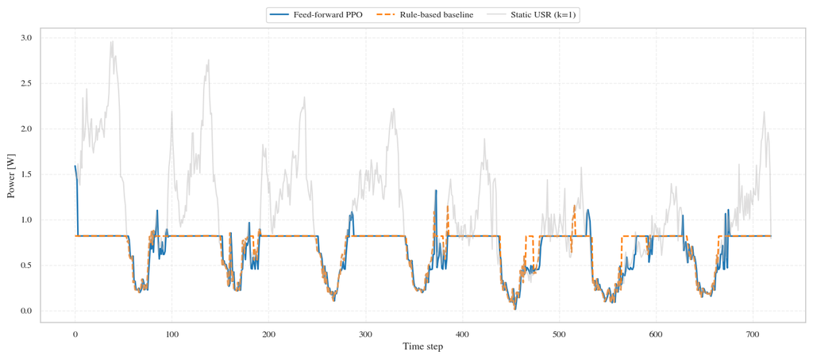

```
Saved: /home/ubuntu/EnergyAwareUPF/experiments/results/paper_results_assets/paper_ready_figures/fig_power_timeline_locked_models.pdf
Saved: /home/ubuntu/EnergyAwareUPF/experiments/results/paper_results_assets/paper_ready_figures/fig_power_timeline_locked_models.png
Saved: /home/ubuntu/EnergyAwareUPF/experiments/results/paper_results_assets/paper_ready_figures/tab_power_timeline_locked_models.csv
Plotted full timeline with power clipped at idle floor: 0.015181814947 W.
```

```python
# 4) Plot power timeline (paper-ready, untrimmed axes)
power_plot_df = power_timeline_locked.copy()

# Clip power to idle floor (from config)
IDLE_WATTS_PER_INSTANCE = 0.0151818149467552
power_plot_df['power'] = pd.to_numeric(power_plot_df['power'], errors='coerce').clip(lower=IDLE_WATTS_PER_INSTANCE)

fig, ax = plt.subplots(constrained_layout=True)
for model_name in ['Feed-forward PPO', 'Rule-based baseline','Static USR (k=1)']: #, 'Static USR (k=1)' , , 'Recurrent PPO'
    g = power_plot_df[power_plot_df['model'] == model_name].sort_values('t').copy()
    ax.plot(
        g['t'], g['power'],
        label=model_name,
        color=PAPER_COLORS[model_name],
        linewidth=1.2 if model_name == 'Static USR (k=1)' else 1.5,
        alpha=0.45 if model_name == 'Static USR (k=1)' else 1.0,
        linestyle='--' if model_name == 'Rule-based baseline' else '-',
    )

ax.set_xlabel('Time step')
ax.set_ylabel('Power [W]')

# Keep full data range and let matplotlib choose y-range so nothing is clipped
ax.relim()
ax.autoscale_view()

ax.grid(True, linestyle='--', alpha=0.35)
ax.legend(
    ncol=4,
    frameon=True,
    loc='upper center',
    bbox_to_anchor=(0.5, 1.07),
    borderaxespad=0.0,
    columnspacing=1.5,
    handlelength=2.0,
    handletextpad=0.6,
 )

paper_fig_dir = PAPER_OUT / 'paper_ready_figures'
paper_fig_dir.mkdir(parents=True, exist_ok=True)

power_plot_pdf = paper_fig_dir / 'fig_power_timeline_locked_models.pdf'
power_plot_png = paper_fig_dir / 'fig_power_timeline_locked_models.png'
power_csv = paper_fig_dir / 'tab_power_timeline_locked_models.csv'

fig.savefig(power_plot_pdf, bbox_inches='tight')
fig.savefig(power_plot_png, bbox_inches='tight')
power_plot_df.to_csv(power_csv, index=False)
plt.show()

print('Saved:', power_plot_pdf.resolve())
print('Saved:', power_plot_png.resolve())
print('Saved:', power_csv.resolve())
print(f'Plotted full timeline with power clipped at idle floor: {IDLE_WATTS_PER_INSTANCE:.12f} W.')
```

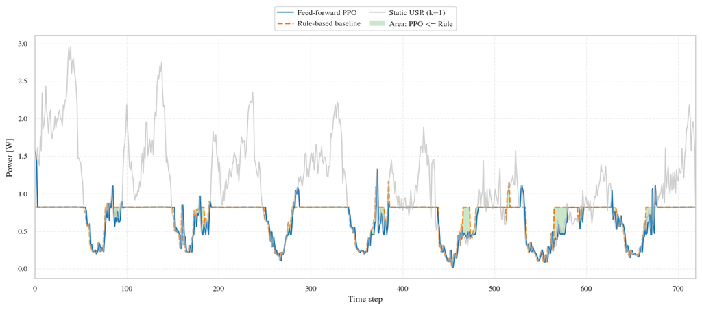

```
Saved: /home/ubuntu/EnergyAwareUPF/experiments/results/paper_results_assets/paper_ready_figures/fig_power_timeline_ff_vs_rule_area_conditional_additional.pdf
Saved: /home/ubuntu/EnergyAwareUPF/experiments/results/paper_results_assets/paper_ready_figures/fig_power_timeline_ff_vs_rule_area_conditional_additional.png
Saved: /home/ubuntu/EnergyAwareUPF/experiments/results/paper_results_assets/paper_ready_figures/tab_power_timeline_ff_vs_rule_area_conditional_additional.csv
Clipped at idle floor: 0.015181814947 W
FF <= Rule steps: 367
FF > Rule steps: 353
```

```python
# 5) Additional plot: Rule-based vs Feed-forward PPO (conditional area between lines)
from matplotlib.lines import Line2D
from matplotlib.patches import Patch

power_plot_df_add = power_timeline_locked.copy()

# Clip power to idle floor (from config)
IDLE_WATTS_PER_INSTANCE = 0.0151818149467552
power_plot_df_add['power'] = pd.to_numeric(power_plot_df_add['power'], errors='coerce').clip(lower=IDLE_WATTS_PER_INSTANCE)

rule_df_add = (
    power_plot_df_add[power_plot_df_add['model'] == 'Rule-based baseline'][['t', 'power']]
    .rename(columns={'power': 'rule_power'})
    .sort_values('t')
)

ff_df_add = (
    power_plot_df_add[power_plot_df_add['model'] == 'Feed-forward PPO'][['t', 'power']]
    .rename(columns={'power': 'ff_power'})
    .sort_values('t')
)

static_usr_df_add = (
    power_plot_df_add[power_plot_df_add['model'] == 'Static USR (k=1)'][['t', 'power']]
    .rename(columns={'power': 'static_usr_power'})
    .sort_values('t')
)

plot_df_add = (
    pd.merge(rule_df_add, ff_df_add, on='t', how='inner')
    .merge(static_usr_df_add, on='t', how='left')
    .dropna(subset=['rule_power', 'ff_power'])
    .sort_values('t')
    .reset_index(drop=True)
)
assert len(plot_df_add) >= 2, 'Need at least 2 aligned points between Rule-based and Feed-forward timelines.'

plot_df_add['ff_lower_or_equal'] = plot_df_add['ff_power'] <= plot_df_add['rule_power']
plot_df_add['ff_vs_rule'] = np.where(plot_df_add['ff_lower_or_equal'], 'FF <= Rule', 'FF > Rule')

x = plot_df_add['t'].to_numpy()
y_rule = plot_df_add['rule_power'].to_numpy()
y_ff = plot_df_add['ff_power'].to_numpy()
y_static_usr = plot_df_add['static_usr_power'].to_numpy()

fig, ax = plt.subplots(constrained_layout=True)

# Reference lines (use universal palette)
ax.plot(
    x, y_rule,
    color=PAPER_COLORS['Rule-based baseline'],
    linewidth=1.6,
    linestyle='--',
)
ax.plot(
    x, y_ff,
    color=PAPER_COLORS['Feed-forward PPO'],
    linewidth=1.35,
    linestyle='-',
)
ax.plot(
    x, y_static_usr,
    color=PAPER_COLORS['Static USR (k=1)'],
    linewidth=1.2,
    linestyle='-',
    alpha=0.65,
)

# Conditional shaded area between lines
mask_ff_better = y_ff <= y_rule
mask_ff_worse = y_ff > y_rule

ax.fill_between(
    x, y_ff, y_rule,
    where=mask_ff_better,
    color='#2ca02c',
    alpha=0.25,
    interpolate=True,
)
# ax.fill_between(
#     x, y_ff, y_rule,
#     where=mask_ff_worse,
#     color='#d62728',
#     alpha=0.25,
#     interpolate=True,
# )

ax.set_xlabel('Time step')
ax.set_ylabel('Power [W]')
ax.set_xlim(x.min(), x.max())
ax.relim()
ax.autoscale_view(scalex=False, scaley=True)
ax.grid(True, linestyle='--', alpha=0.35)

legend_handles = [
    Line2D([0], [0], color=PAPER_COLORS['Feed-forward PPO'], lw=1.35, ls='-', label='Feed-forward PPO'),
    Line2D([0], [0], color=PAPER_COLORS['Rule-based baseline'], lw=1.6, ls='--', label='Rule-based baseline'),
    Line2D([0], [0], color=PAPER_COLORS['Static USR (k=1)'], lw=1.2, ls='-', label='Static USR (k=1)'),
    Patch(facecolor='#2ca02c', edgecolor='none', alpha=0.25, label='Area: PPO <= Rule'),
#     Patch(facecolor='#d62728', edgecolor='none', alpha=0.25, label='Area: PPO > Rule'),
]
ax.legend(
    handles=legend_handles,
    ncol=2,
    frameon=True,
    loc='upper center',
    bbox_to_anchor=(0.5, 1.12),
    borderaxespad=0.0,
    columnspacing=1.1,
    handlelength=2.0,
    handletextpad=0.5,
)

paper_fig_dir = PAPER_OUT / 'paper_ready_figures'
paper_fig_dir.mkdir(parents=True, exist_ok=True)

power_plot_pdf_add = paper_fig_dir / 'fig_power_timeline_ff_vs_rule_area_conditional_additional.pdf'
power_plot_png_add = paper_fig_dir / 'fig_power_timeline_ff_vs_rule_area_conditional_additional.png'
power_csv_add = paper_fig_dir / 'tab_power_timeline_ff_vs_rule_area_conditional_additional.csv'

fig.savefig(power_plot_pdf_add, bbox_inches='tight')
fig.savefig(power_plot_png_add, bbox_inches='tight')
plot_df_add.to_csv(power_csv_add, index=False)
plt.show()

print('Saved:', power_plot_pdf_add.resolve())
print('Saved:', power_plot_png_add.resolve())
print('Saved:', power_csv_add.resolve())
print(f'Clipped at idle floor: {IDLE_WATTS_PER_INSTANCE:.12f} W')
print('FF <= Rule steps:', int(plot_df_add['ff_lower_or_equal'].sum()))
print('FF > Rule steps:', int((~plot_df_add['ff_lower_or_equal']).sum()))
```

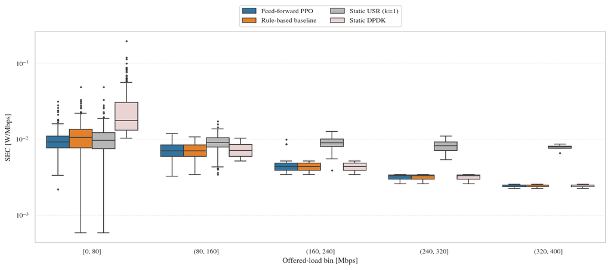

```
Saved: /home/ubuntu/EnergyAwareUPF/experiments/results/paper_results_assets/paper_ready_figures/fig_sec_by_offered_load_bin_5models.pdf
Saved: /home/ubuntu/EnergyAwareUPF/experiments/results/paper_results_assets/paper_ready_figures/fig_sec_by_offered_load_bin_5models.png
Saved: /home/ubuntu/EnergyAwareUPF/experiments/results/paper_results_assets/paper_ready_figures/tab_sec_by_offered_load_bin_5models.csv
Controllers included: Feed-forward PPO, Rule-based baseline, Static DPDK, Static USR (k=1)
Fixed bin edges: [0, 80, 160, 240, 320, 400]
```

```python
# 6) Next plot: SEC by offered-load bins (FF, Recurrent, Rule, Static USR, Static DPDK)
sec_models = [
    'Feed-forward PPO',
    # 'Recurrent PPO',
    'Rule-based baseline',
    'Static USR (k=1)',
    'Static DPDK',
]

# Ensure Static DPDK is available in the local plotting dataframe
power_plot_df_sec = power_timeline_locked.copy()
if 'Static DPDK' not in set(power_plot_df_sec['model'].unique()):
    static_dpdk_csv = BASELINES_ROOT / 'baseline_static_dpdk_results.csv'
    assert static_dpdk_csv.exists(), f'Missing static DPDK CSV: {static_dpdk_csv.resolve()}'
    static_dpdk_tl = _load_rule_power_timeline(static_dpdk_csv, 'Static DPDK')
    power_plot_df_sec = pd.concat([power_plot_df_sec, static_dpdk_tl], ignore_index=True)

# Clip power to idle floor
IDLE_WATTS_PER_INSTANCE = 0.0151818149467552
power_plot_df_sec['power'] = pd.to_numeric(power_plot_df_sec['power'], errors='coerce').clip(lower=IDLE_WATTS_PER_INSTANCE)

# Use offered load trace from feed-forward eval as common reference
ff_src = Path(ff_tl['source_file'].dropna().iloc[0])
ff_raw = pd.read_csv(ff_src)
if 'traffic' in ff_raw.columns:
    traffic_ref = pd.DataFrame({
        't': np.arange(len(ff_raw)),
        'traffic': pd.to_numeric(ff_raw['traffic'], errors='coerce'),
    })
elif 'Actual_Traffic' in ff_raw.columns:
    traffic_ref = pd.DataFrame({
        't': np.arange(len(ff_raw)),
        'traffic': pd.to_numeric(ff_raw['Actual_Traffic'], errors='coerce'),
    })
else:
    raise KeyError(f'No traffic column found in feed-forward source file: {ff_src.resolve()}')

# Build SEC dataframe for requested controllers
sec_parts = []
for model_name in sec_models:
    g = (
        power_plot_df_sec[power_plot_df_sec['model'] == model_name][['t', 'power']]
        .sort_values('t')
        .copy()
    )
    if g.empty:
        continue
    m = pd.merge(g, traffic_ref, on='t', how='inner').dropna(subset=['power', 'traffic'])
    m['sec'] = m['power'] / np.maximum(m['traffic'], EPS)
    m['controller'] = model_name
    sec_parts.append(m)

sec_df = pd.concat(sec_parts, ignore_index=True) if sec_parts else pd.DataFrame()
assert not sec_df.empty, 'SEC plot dataframe is empty.'

# Offered-load bins (fixed-width 80 Mbps from 0 to rounded-up max traffic)
bin_width = 80
max_traffic = float(sec_df['traffic'].max())
max_rounded = int(np.ceil(max_traffic / bin_width) * bin_width) if np.isfinite(max_traffic) else bin_width
max_rounded = max(bin_width, max_rounded)
bin_edges = np.arange(0, max_rounded + bin_width, bin_width)
sec_df['load_bin'] = pd.cut(sec_df['traffic'], bins=bin_edges, include_lowest=True)

# Human-readable integer bin labels
bin_categories = list(sec_df['load_bin'].cat.categories)
bin_labels = []
for i, b in enumerate(bin_categories):
    left_i = int(np.floor(b.left))
    right_i = int(np.ceil(b.right))
    if i == 0:
        label = f'[0, {right_i}]'
    else:
        label = f'({left_i}, {right_i}]'
    bin_labels.append(label)

bin_label_map = dict(zip(bin_categories, bin_labels))
sec_df['load_bin_label'] = sec_df['load_bin'].map(bin_label_map)

# Palette with fallback for Static DPDK if not defined globally
sec_palette = dict(PAPER_COLORS)
if 'Static DPDK' not in sec_palette:
    sec_palette['Static DPDK'] = '#ecd0d0'

fig, ax = plt.subplots(figsize=(11, 4.8), constrained_layout=True)
sns.boxplot(
    data=sec_df,
    x='load_bin_label',
    y='sec',
    hue='controller',
    order=bin_labels,
    hue_order=sec_models,
    palette=sec_palette,
    fliersize=1.5,
    ax=ax,
 )
ax.set_xlabel('Offered-load bin [Mbps]')
ax.set_ylabel('SEC [W/Mbps]')
ax.set_yscale('log')
# ax.set_title('Specific energy consumption by offered-load bin')
ax.tick_params(axis='x')
ax.grid(True, axis='y', linestyle='--', alpha=0.35)
ax.legend(ncol=2, frameon=True, loc='upper center', bbox_to_anchor=(0.5, 1.14))

paper_fig_dir = PAPER_OUT / 'paper_ready_figures'
paper_fig_dir.mkdir(parents=True, exist_ok=True)

sec_plot_pdf = paper_fig_dir / 'fig_sec_by_offered_load_bin_5models.pdf'
sec_plot_png = paper_fig_dir / 'fig_sec_by_offered_load_bin_5models.png'
sec_plot_csv = paper_fig_dir / 'tab_sec_by_offered_load_bin_5models.csv'

fig.savefig(sec_plot_pdf, bbox_inches='tight')
fig.savefig(sec_plot_png, bbox_inches='tight')
sec_df.to_csv(sec_plot_csv, index=False)
plt.show()

print('Saved:', sec_plot_pdf.resolve())
print('Saved:', sec_plot_png.resolve())
print('Saved:', sec_plot_csv.resolve())
print('Controllers included:', ', '.join(sorted(sec_df['controller'].unique())))
print('Fixed bin edges:', [int(e) for e in bin_edges])
```

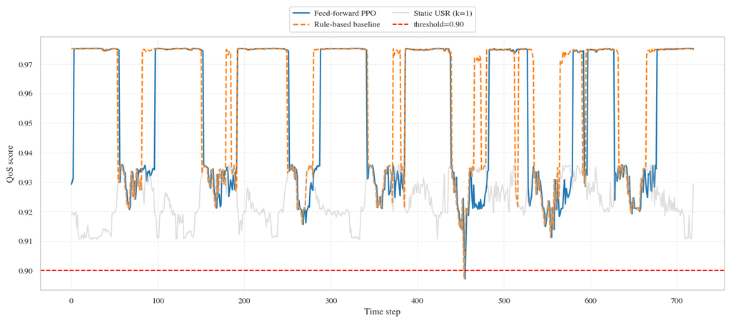

```
Saved: /home/ubuntu/EnergyAwareUPF/experiments/results/paper_results_assets/paper_ready_figures/fig_qos_timeline_locked_models.pdf
Saved: /home/ubuntu/EnergyAwareUPF/experiments/results/paper_results_assets/paper_ready_figures/fig_qos_timeline_locked_models.png
Saved: /home/ubuntu/EnergyAwareUPF/experiments/results/paper_results_assets/paper_ready_figures/tab_qos_timeline_locked_models.csv
Step counts before sync: {'Feed-forward PPO': 720, 'Rule-based baseline': 720, 'Static USR (k=1)': 720}
Synchronized to common steps: 720
```

```python
# 7) Next plot: QoS timeline (same style/model set as power timeline)
def _load_rl_qos_timeline(run_dir: Path, label: str) -> pd.DataFrame:
    eval_dir = run_dir / 'eval'
    timeline_files = sorted(eval_dir.glob('timeline_*.csv'))
    result_files = sorted(eval_dir.glob('evaluation_results*.csv'))

    # Prefer evaluation_results for QoS (timeline files may not include QoS)
    src = result_files[-1] if result_files else (timeline_files[-1] if timeline_files else None)
    if src is None:
        raise FileNotFoundError(f'No timeline/evaluation CSV found under {eval_dir.resolve()}')

    df = pd.read_csv(src)
    df = _enforce_rl_720_steps(df)
    if 'performance' in df.columns:
        qos_series = pd.to_numeric(df['performance'], errors='coerce')
    elif 'qos' in df.columns:
        qos_series = pd.to_numeric(df['qos'], errors='coerce')
    elif 'QoS_Score_Actual' in df.columns:
        qos_series = pd.to_numeric(df['QoS_Score_Actual'], errors='coerce')
    else:
        raise KeyError(f'QoS column not found in {src.resolve()}')

    out = pd.DataFrame({
        't': np.arange(len(df)),
        'qos': qos_series,
        'model': label,
    })
    out['source_file'] = str(src)
    return out

def _load_baseline_qos_timeline(csv_path: Path, label: str) -> pd.DataFrame:
    df = pd.read_csv(csv_path)
    if 'QoS_Score_Actual' in df.columns:
        qos_series = pd.to_numeric(df['QoS_Score_Actual'], errors='coerce')
    elif 'QoS_Score_OAI1x' in df.columns:
        qos_series = pd.to_numeric(df['QoS_Score_OAI1x'], errors='coerce')
    elif 'performance' in df.columns:
        qos_series = pd.to_numeric(df['performance'], errors='coerce')
    else:
        raise KeyError(f'QoS column not found in baseline file: {csv_path.resolve()}')

    out = pd.DataFrame({
        't': np.arange(len(df)),
        'qos': qos_series,
        'model': label,
    })
    out['source_file'] = str(csv_path)
    return out

qos_timelines_locked = [
    _load_rl_qos_timeline(ff_run_dir, 'Feed-forward PPO'),
    _load_rl_qos_timeline(rec_run_dir, 'Recurrent PPO'),
    _load_baseline_qos_timeline(rule_csv, 'Rule-based baseline'),
    _load_baseline_qos_timeline(static_usr_csv, 'Static USR (k=1)'),
]
qos_timeline_locked = pd.concat(qos_timelines_locked, ignore_index=True)

# Keep plotted models on the same step horizon (fixes step-count mismatch across sources)
qos_models_plot = ['Feed-forward PPO', 'Rule-based baseline', 'Static USR (k=1)']
pre_counts = (
    qos_timeline_locked[qos_timeline_locked['model'].isin(qos_models_plot)]
    .groupby('model')['t']
    .max()
    .add(1)
    .astype(int)
    .sort_index()
 )
assert not pre_counts.empty, 'No QoS timelines found for plotted models.'
common_steps = int(pre_counts.min())
qos_timeline_locked = qos_timeline_locked[qos_timeline_locked['t'] < common_steps].copy()

fig, ax = plt.subplots(constrained_layout=True)
for model_name in qos_models_plot:
    g = qos_timeline_locked[qos_timeline_locked['model'] == model_name].sort_values('t').copy()
    ax.plot(
        g['t'], g['qos'],
        label=model_name,
        color=PAPER_COLORS[model_name],
        linewidth=1.2 if model_name == 'Static USR (k=1)' else 1.5,
        alpha=0.45 if model_name == 'Static USR (k=1)' else 1.0,
        linestyle='--' if model_name == 'Rule-based baseline' else '-',
    )

ax.axhline(TAU, linestyle='--', color='red', linewidth=1.2, label=f'threshold={TAU:.2f}')

ax.set_xlabel('Time step')
ax.set_ylabel('QoS score')
# ax.set_yscale('log')

ax.relim()
ax.autoscale_view()

ax.grid(True, linestyle='--', alpha=0.35)
ax.legend(
    ncol=2,
    frameon=True,
    loc='upper center',
    bbox_to_anchor=(0.5, 1.12),
    borderaxespad=0.0,
    columnspacing=1.5,
    handlelength=2.0,
    handletextpad=0.6,
)

paper_fig_dir = PAPER_OUT / 'paper_ready_figures'
paper_fig_dir.mkdir(parents=True, exist_ok=True)

qos_plot_pdf = paper_fig_dir / 'fig_qos_timeline_locked_models.pdf'
qos_plot_png = paper_fig_dir / 'fig_qos_timeline_locked_models.png'
qos_csv = paper_fig_dir / 'tab_qos_timeline_locked_models.csv'

fig.savefig(qos_plot_pdf, bbox_inches='tight')
fig.savefig(qos_plot_png, bbox_inches='tight')
qos_timeline_locked[qos_timeline_locked['model'].isin(qos_models_plot)].to_csv(qos_csv, index=False)
plt.show()

print('Saved:', qos_plot_pdf.resolve())
print('Saved:', qos_plot_png.resolve())
print('Saved:', qos_csv.resolve())
print('Step counts before sync:', pre_counts.to_dict())
print('Synchronized to common steps:', common_steps)
```

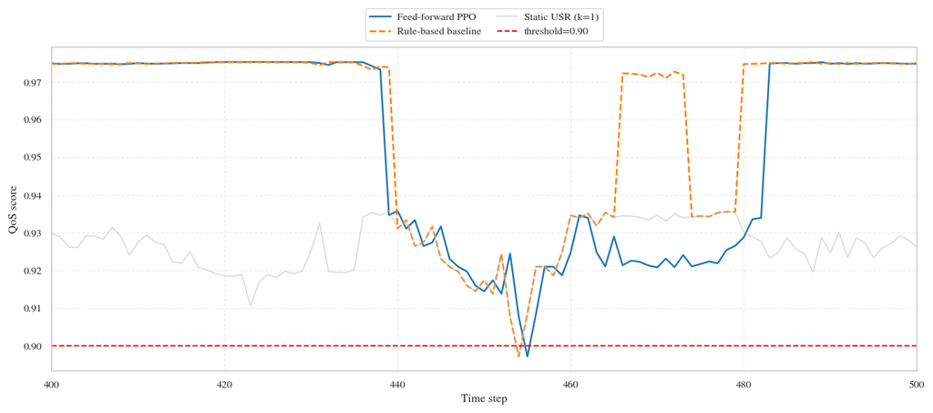

```
Saved: /home/ubuntu/EnergyAwareUPF/experiments/results/paper_results_assets/paper_ready_figures/fig_qos_timeline_locked_models_t400_500.pdf
Saved: /home/ubuntu/EnergyAwareUPF/experiments/results/paper_results_assets/paper_ready_figures/fig_qos_timeline_locked_models_t400_500.png
Saved: /home/ubuntu/EnergyAwareUPF/experiments/results/paper_results_assets/paper_ready_figures/tab_qos_timeline_locked_models_t400_500.csv
Window: 400 to 500
Unique step count in zoom window: {'Feed-forward PPO': 101, 'Rule-based baseline': 101, 'Static USR (k=1)': 101}
```

```python
# 8) Zoomed plot: QoS timeline focused on steps 400 to 500 (same style/model set)
qos_models_plot = ['Feed-forward PPO', 'Rule-based baseline', 'Static USR (k=1)']
qos_zoom_df = qos_timeline_locked[
    qos_timeline_locked['model'].isin(qos_models_plot)
    & (pd.to_numeric(qos_timeline_locked['t'], errors='coerce') >= 400)
    & (pd.to_numeric(qos_timeline_locked['t'], errors='coerce') <= 500)
][["t", "qos", "model", "source_file"]].copy()

assert not qos_zoom_df.empty, 'No QoS samples found in the requested time window [400, 500] after step synchronization.'

fig, ax = plt.subplots(constrained_layout=True)
for model_name in qos_models_plot:
    g = qos_zoom_df[qos_zoom_df['model'] == model_name].sort_values('t').copy()
    ax.plot(
        g['t'], g['qos'],
        label=model_name,
        color=PAPER_COLORS[model_name],
        linewidth=1.2 if model_name == 'Static USR (k=1)' else 1.5,
        alpha=0.45 if model_name == 'Static USR (k=1)' else 1.0,
        linestyle='--' if model_name == 'Rule-based baseline' else '-',
    )

ax.axhline(TAU, linestyle='--', color='red', linewidth=1.2, label=f'threshold={TAU:.2f}')

ax.set_xlabel('Time step')
ax.set_ylabel('QoS score')
ax.set_xlim(400, 500)
ax.relim()
ax.autoscale_view(scalex=False, scaley=True)

ax.grid(True, linestyle='--', alpha=0.35)
ax.legend(
    ncol=2,
    frameon=True,
    loc='upper center',
    bbox_to_anchor=(0.5, 1.12),
    borderaxespad=0.0,
    columnspacing=1.5,
    handlelength=2.0,
    handletextpad=0.6,
 )

paper_fig_dir = PAPER_OUT / 'paper_ready_figures'
paper_fig_dir.mkdir(parents=True, exist_ok=True)

qos_zoom_pdf = paper_fig_dir / 'fig_qos_timeline_locked_models_t400_500.pdf'
qos_zoom_png = paper_fig_dir / 'fig_qos_timeline_locked_models_t400_500.png'
qos_zoom_csv = paper_fig_dir / 'tab_qos_timeline_locked_models_t400_500.csv'

fig.savefig(qos_zoom_pdf, bbox_inches='tight')
fig.savefig(qos_zoom_png, bbox_inches='tight')
qos_zoom_df.to_csv(qos_zoom_csv, index=False)
plt.show()

print('Saved:', qos_zoom_pdf.resolve())
print('Saved:', qos_zoom_png.resolve())
print('Saved:', qos_zoom_csv.resolve())
print('Window:', int(qos_zoom_df['t'].min()), 'to', int(qos_zoom_df['t'].max()))
print('Unique step count in zoom window:', qos_zoom_df.groupby('model')['t'].nunique().to_dict())
```

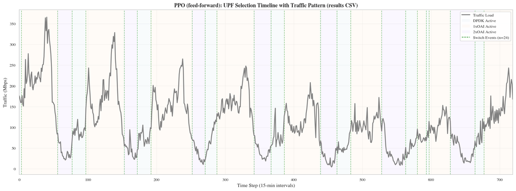

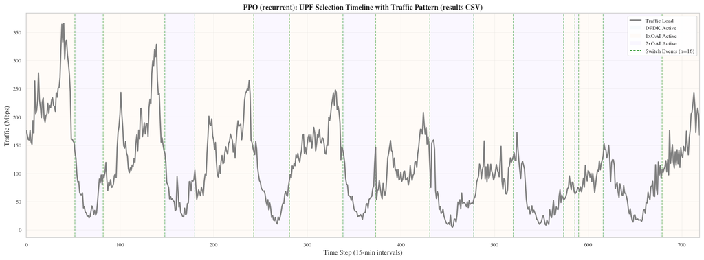

```python
# RL Switching Event Timeline Plots (separate, using results CSV)
import matplotlib.pyplot as plt
from matplotlib.patches import Patch
import numpy as np

# Use timeline_df already loaded from results CSVs
# Separate plots for each RL model
K = 2  # Number of OAI instances (adjust as needed)
labels_order = ['1xOAI', '2xOAI', 'DPDK']
upf_colors = {'DPDK': '#E8F4F8', '1xOAI': '#FFF4E6', '2xOAI': '#F0E6FF'}

for model_name in ['PPO (feed-forward)', 'PPO (recurrent)']:
    df = timeline_df[timeline_df['controller'] == model_name].copy()
    df = _enforce_rl_720_steps(df)
    exec_ord = df['action'].fillna(0).astype(int)
    upf_configs = [labels_order[code] if code < len(labels_order) else 'DPDK' for code in exec_ord]
    t = np.arange(len(df))

    fig, ax = plt.subplots(figsize=(16, 6))
    # Background zones
    current_config = upf_configs[0]
    start_idx = 0
    for i in range(1, len(upf_configs) + 1):
        if i == len(upf_configs) or upf_configs[i] != current_config:
            color = upf_colors.get(current_config, '#F5F5F5')
            ax.axvspan(start_idx, i-1, alpha=0.3, color=color, zorder=1)
            if i < len(upf_configs):
                current_config = upf_configs[i]
                start_idx = i
    # Traffic line
    if 'traffic' in df:
        ax.plot(t, df['traffic'], label='Traffic Load', color='gray', linewidth=2, zorder=3)
        ax.set_ylabel('Traffic (Mbps)', fontsize=11)
    # Switch event markers
    switch_indices = [i for i in range(1, len(upf_configs)) if upf_configs[i] != upf_configs[i-1]]
    for idx in switch_indices:
        ax.axvline(x=idx, color='green', linestyle='--', linewidth=1, alpha=0.5, zorder=2)
    # Legend
    legend_elements = [
        plt.Line2D([0], [0], color='gray', linewidth=2, label='Traffic Load'),
        Patch(facecolor=upf_colors['DPDK'], alpha=0.3, label='DPDK Active'),
        Patch(facecolor=upf_colors['1xOAI'], alpha=0.3, label='1xOAI Active'),
        Patch(facecolor=upf_colors['2xOAI'], alpha=0.3, label='2xOAI Active'),
        plt.Line2D([0], [0], color='green', linestyle='--', linewidth=1, label=f'Switch Events (n={len(switch_indices)})')
    ]
    ax.set_xlabel('Time Step (15-min intervals)', fontsize=11)
    ax.set_title(f'{model_name}: UPF Selection Timeline with Traffic Pattern (results CSV)', fontsize=12, fontweight='bold')
    ax.legend(handles=legend_elements, loc='upper right', fontsize=9, framealpha=0.95)
    ax.grid(True, alpha=0.3, zorder=0)
    ax.set_xlim(left=0, right=len(t)-1)
    plt.tight_layout()
    plt.show()
```

```
PPO (feed-forward) upf_configs_plot: ['2xUSR', '2xUSR', '2xUSR', 'DPDK', 'DPDK', 'DPDK', 'DPDK', 'DPDK', 'DPDK', 'DPDK', 'DPDK', 'DPDK', 'DPDK', 'DPDK', 'DPDK', 'DPDK', 'DPDK', 'DPDK', 'DPDK', 'DPDK', 'DPDK', 'DPDK', 'DPDK', 'DPDK', 'DPDK', 'DPDK', 'DPDK', 'DPDK', 'DPDK', 'DPDK', 'DPDK', 'DPDK', 'DP…
PPO (feed-forward) switch_indices: [3, 56, 97, 153, 192, 252, 288, 342, 386, 439, 483, 528, 580, 593, 597, 628, 677]
PPO (feed-forward) scale_indices: [77, 172, 271, 367, 463, 563, 664]
```

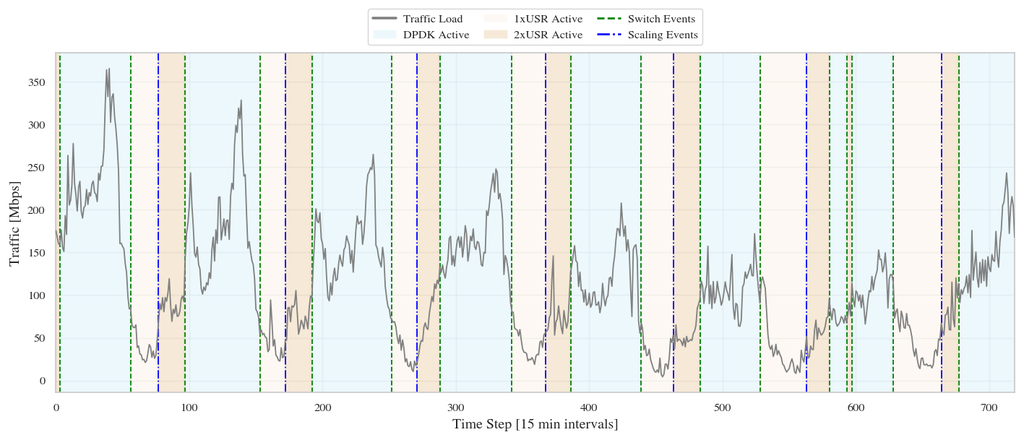

```
Saved: /home/ubuntu/EnergyAwareUPF/experiments/results/paper_results_assets/paper_ready_figures/fig_switching_timeline_PPO_feed-forward.pdf
Saved: /home/ubuntu/EnergyAwareUPF/experiments/results/paper_results_assets/paper_ready_figures/fig_switching_timeline_PPO_feed-forward.png
PPO (recurrent) upf_configs_plot: ['DPDK', 'DPDK', 'DPDK', 'DPDK', 'DPDK', 'DPDK', 'DPDK', 'DPDK', 'DPDK', 'DPDK', 'DPDK', 'DPDK', 'DPDK', 'DPDK', 'DPDK', 'DPDK', 'DPDK', 'DPDK', 'DPDK', 'DPDK', 'DPDK', 'DPDK', 'DPDK', 'DPDK', 'DPDK', 'DPDK', 'DPDK', 'DPDK', 'DPDK', 'DPDK', 'DPDK', 'DPDK', 'DPDK', '…
PPO (recurrent) switch_indices: [52, 82, 148, 180, 243, 281, 338, 373, 431, 478, 520, 574, 586, 590, 616, 679]
PPO (recurrent) scale_indices: []
```

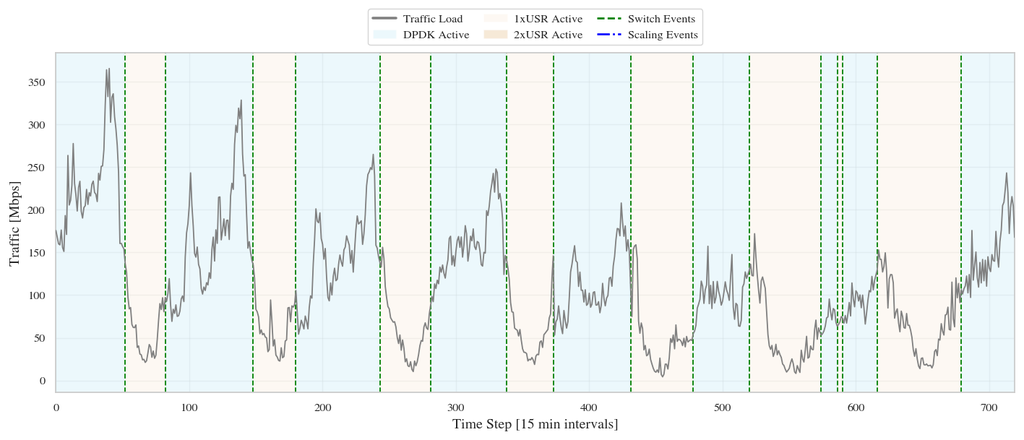

```
Saved: /home/ubuntu/EnergyAwareUPF/experiments/results/paper_results_assets/paper_ready_figures/fig_switching_timeline_PPO_recurrent.pdf
Saved: /home/ubuntu/EnergyAwareUPF/experiments/results/paper_results_assets/paper_ready_figures/fig_switching_timeline_PPO_recurrent.png
```

```python
# RL Switching Event Timeline Plots (separate, OAI→USR label replacement, correct event logic, save figures)
import matplotlib.pyplot as plt
from matplotlib.patches import Patch
import numpy as np
from pathlib import Path

K = 2  # Number of OAI instances (adjust as needed)
labels_order = ['DPDK', '1xOAI', '2xOAI']
upf_colors = {'DPDK': "#C2EAF8", '1xOAI': "#F9EBD9", '2xOAI': "#E3B77D"}
PAPER_OUT = Path('/home/ubuntu/EnergyAwareUPF/experiments/results/paper_results_assets')
PAPER_OUT.mkdir(parents=True, exist_ok=True)

for model_name in ['PPO (feed-forward)', 'PPO (recurrent)']:
    df = timeline_df[timeline_df['controller'] == model_name].copy()
    df = _enforce_rl_720_steps(df)
    exec_ord = df['action'].fillna(0).astype(int)
    upf_configs = [labels_order[code] if code < len(labels_order) else 'DPDK' for code in exec_ord]
    # Replace OAI with USR in plot labels
    upf_configs_plot = [cfg.replace('OAI', 'USR') for cfg in upf_configs]
    t = np.arange(len(df))
    print(f"{model_name} upf_configs_plot: {upf_configs_plot}")

    fig, ax = plt.subplots(figsize=(11, 4.8), constrained_layout=True)
    # Background zones
    current_config = upf_configs_plot[0]
    start_idx = 0
    for i in range(1, len(upf_configs_plot) + 1):
        if i == len(upf_configs_plot) or upf_configs_plot[i] != current_config:
            color = upf_colors.get(current_config.replace('USR', 'OAI'), '#F5F5F5')
            ax.axvspan(start_idx, i-1, alpha=0.3, color=color, zorder=1)
            if i < len(upf_configs_plot):
                current_config = upf_configs_plot[i]
                start_idx = i
    # Traffic line
    if 'traffic' in df:
        ax.plot(t, df['traffic'], label='Traffic Load', color='gray', linewidth=1, zorder=3)
        ax.set_ylabel('Traffic [Mbps]', fontsize=11)
    # Switching and scaling event markers
    switch_indices = []
    scale_indices = []
    for i in range(1, len(upf_configs_plot)):
        prev, curr = upf_configs_plot[i-1], upf_configs_plot[i]
        # Switching: DPDK <-> 1xUSR or DPDK <-> 2xUSR
        if (prev == 'DPDK' and curr in ['1xUSR', '2xUSR']) or (curr == 'DPDK' and prev in ['1xUSR', '2xUSR']):
            switch_indices.append(i)
        # Scaling: 1xUSR <-> 2xUSR
        elif (prev == '1xUSR' and curr == '2xUSR') or (prev == '2xUSR' and curr == '1xUSR'):
            scale_indices.append(i)
    print(f"{model_name} switch_indices: {switch_indices}")
    print(f"{model_name} scale_indices: {scale_indices}")
    for idx in switch_indices:
        ax.axvline(x=idx, color='green', linestyle='--', linewidth=1, alpha=1.0, zorder=2)
    for idx in scale_indices:
        ax.axvline(x=idx, color='blue', linestyle='-.', linewidth=1, alpha=1.0, zorder=2)
    # Legend
    legend_elements = [
        plt.Line2D([0], [0], color='gray', linewidth=2, label='Traffic Load'),
        Patch(facecolor=upf_colors['DPDK'], alpha=0.3, label='DPDK Active'),
        Patch(facecolor=upf_colors['1xOAI'], alpha=0.3, label='1xUSR Active'),
        Patch(facecolor=upf_colors['2xOAI'], alpha=0.3, label='2xUSR Active'),
        plt.Line2D([0], [0], color='green', linestyle='--', linewidth=1.5, label=f'Switch Events'),
        plt.Line2D([0], [0], color='blue', linestyle='-.', linewidth=1.5, label=f'Scaling Events'),
    ]
    ax.set_xlabel('Time Step [15 min intervals]', fontsize=11)
    # No title
    ax.legend(handles=legend_elements, ncol=3, frameon=True, loc='upper center', bbox_to_anchor=(0.5, 1.13), borderaxespad=0.0, columnspacing=1.2, handlelength=2.0, handletextpad=0.6)
    ax.grid(True, alpha=0.3, zorder=0)
    ax.set_xlim(left=0, right=len(t)-1)
    plt.tight_layout()
    # Save figures
    fig_dir = PAPER_OUT / 'paper_ready_figures'
    fig_dir.mkdir(parents=True, exist_ok=True)
    fig_pdf = fig_dir / f'fig_switching_timeline_{model_name.replace(" ", "_").replace("(","").replace(")","")}.pdf'
    fig_png = fig_dir / f'fig_switching_timeline_{model_name.replace(" ", "_").replace("(","").replace(")","")}.png'
    fig.savefig(fig_pdf, bbox_inches='tight')
    fig.savefig(fig_png, bbox_inches='tight')
    plt.show()
    print('Saved:', fig_pdf.resolve())
    print('Saved:', fig_png.resolve())
```

[output not shown]

[output not shown]

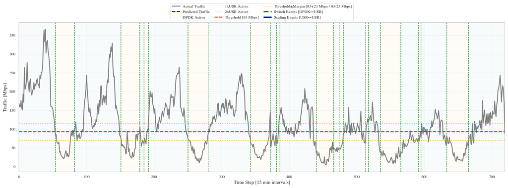

```
Saved: /home/ubuntu/EnergyAwareUPF/experiments/results/paper_results_assets/paper_ready_figures/fig_switching_timeline_rule_based_baseline.pdf
Saved: /home/ubuntu/EnergyAwareUPF/experiments/results/paper_results_assets/paper_ready_figures/fig_switching_timeline_rule_based_baseline.png
```

```python
# Rule-based Baseline Switching Event Timeline Plot with Traffic Throughput and Threshold Margins, including Predicted Traffic
import matplotlib.pyplot as plt
from matplotlib.patches import Patch
import numpy as np
from pathlib import Path

labels_order = ['DPDK', '1xOAI', '2xOAI']
upf_colors = {'DPDK': '#E8F4F8', '1xOAI': '#FFF4E6', '2xOAI': '#F0E6FF'}
PAPER_OUT = Path('/home/ubuntu/EnergyAwareUPF/experiments/results/paper_results_assets')
PAPER_OUT.mkdir(parents=True, exist_ok=True)

THRESHOLD = 93
MARGIN = 23

model_name = 'Rule-based baseline'
df = timeline_df[timeline_df['controller'] == model_name].copy()
df = _enforce_rl_720_steps(df)
exec_ord = df['action'].fillna(0).astype(int)
upf_configs = [labels_order[code] if code < len(labels_order) else 'DPDK' for code in exec_ord]
upf_configs_plot = [cfg.replace('OAI', 'USR') for cfg in upf_configs]
t = np.arange(len(df))

fig, ax = plt.subplots(figsize=(16, 6))
# Background zones
current_config = upf_configs_plot[0]
start_idx = 0
for i in range(1, len(upf_configs_plot) + 1):
    if i == len(upf_configs_plot) or upf_configs_plot[i] != current_config:
        color = upf_colors.get(current_config.replace('USR', 'OAI'), '#F5F5F5')
        ax.axvspan(start_idx, i-1, alpha=0.3, color=color, zorder=1)
        if i < len(upf_configs_plot):
            current_config = upf_configs_plot[i]
            start_idx = i
# Traffic line
print(df.columns)
if 'traffic' in df:
    ax.plot(t, df['traffic'], label='Actual Traffic', color='gray', linewidth=2, zorder=3)
    ax.set_ylabel('Traffic [Mbps]', fontsize=11)
# Predicted traffic line
if 'predicted_traffic' in df:
    ax.plot(t, df['predicted_traffic'], label='Predicted Traffic', color='blue', linewidth=2, linestyle='--', zorder=4)
# Threshold and margins
ax.axhline(THRESHOLD, color='red', linestyle='--', linewidth=2, label=f'Threshold [{THRESHOLD} Mbps]', zorder=5)
ax.axhline(THRESHOLD + MARGIN, color='orange', linestyle=':', linewidth=1.5, label=f'Threshold+Margin [{THRESHOLD+MARGIN} Mbps]', zorder=5)
ax.axhline(THRESHOLD - MARGIN, color='orange', linestyle=':', linewidth=1.5, label=f'Threshold-Margin [{THRESHOLD-MARGIN} Mbps]', zorder=5)
# Switching and scaling event markers
switch_indices = []
scale_indices = []
for i in range(1, len(upf_configs_plot)):
    prev, curr = upf_configs_plot[i-1], upf_configs_plot[i]
    if (prev == 'DPDK' and curr in ['1xUSR', '2xUSR']) or (curr == 'DPDK' and prev in ['1xUSR', '2xUSR']):
        switch_indices.append(i)
    elif (prev == '1xUSR' and curr == '2xUSR') or (prev == '2xUSR' and curr == '1xUSR'):
        scale_indices.append(i)
for idx in switch_indices:
    ax.axvline(x=idx, color='green', linestyle='--', linewidth=1, alpha=1.0, zorder=2)
for idx in scale_indices:
    ax.axvline(x=idx, color='blue', linestyle='-.', linewidth=1, alpha=1.0, zorder=2)
# Legend
legend_elements = [
    plt.Line2D([0], [0], color='gray', linewidth=2, label='Actual Traffic'),
    plt.Line2D([0], [0], color='blue', linewidth=2, linestyle='--', label='Predicted Traffic'),
    Patch(facecolor=upf_colors['DPDK'], alpha=0.3, label='DPDK Active'),
    Patch(facecolor=upf_colors['1xOAI'], alpha=0.3, label='1xUSR Active'),
    Patch(facecolor=upf_colors['2xOAI'], alpha=0.3, label='2xUSR Active'),
    plt.Line2D([0], [0], color='red', linestyle='--', linewidth=2, label=f'Threshold [{THRESHOLD} Mbps]'),
    plt.Line2D([0], [0], color='orange', linestyle=':', linewidth=1.5, label=f'Threshold±Margin [{THRESHOLD}+{MARGIN} Mbps / {THRESHOLD}-{MARGIN} Mbps]'),
    plt.Line2D([0], [0], color='green', linestyle='--', linewidth=3, label=f'Switch Events [DPDK↔USR]'),
    plt.Line2D([0], [0], color='blue', linestyle='-.', linewidth=3, label=f'Scaling Events [USR↔USR]'),
    ]
ax.set_xlabel('Time Step [15 min intervals]', fontsize=11)
ax.legend(handles=legend_elements, ncol=3, frameon=True, loc='upper center', bbox_to_anchor=(0.5, 1.13), borderaxespad=0.0, columnspacing=1.2, handlelength=2.0, handletextpad=0.6)
ax.grid(True, alpha=0.3, zorder=0)
ax.set_xlim(left=0, right=len(t)-1)
plt.tight_layout()
# Save figures
fig_dir = PAPER_OUT / 'paper_ready_figures'
fig_dir.mkdir(parents=True, exist_ok=True)
fig_pdf = fig_dir / f'fig_switching_timeline_rule_based_baseline.pdf'
fig_png = fig_dir / f'fig_switching_timeline_rule_based_baseline.png'
fig.savefig(fig_pdf, bbox_inches='tight')
fig.savefig(fig_png, bbox_inches='tight')
plt.show()
print('Saved:', fig_pdf.resolve())
print('Saved:', fig_png.resolve())
```